# Analysis of Exposure Data for the ROCKS Chemical Collection

This code includes analysis of chemical, use, emission, media occurrence, and intake data, and generation of figures supporting the manuscript: Isaacs, KK, Wambaugh JF, Charest N, Sinclair G, Shapiro AJ, Whitehead H, Boatman A, Ferland TM, Wall JT, Wilson M, Sams RL, Edwards S, Thomas RS, and Paul Friedman K. Characterizing Exposure Pathways for a Global Collection of Chemicals. Submitted to Environmental Science and Technology.

Code: Kristin Isaacs, 10/2026

Setup

```r
source("ROCKSsetup.R")
```

[output not shown]

[output not shown]

```r
preview_png <- function(
  png_file,
  scale = 0.25,
  suffix = "_preview"
) {

  stopifnot(file.exists(png_file))

  info <- png::readPNG(png_file, info = TRUE)
  dims <- attr(info, "dim")

  new_width  <- max(1, round(dims[2] * scale))
  new_height <- max(1, round(dims[1] * scale))

  # Unique preview filename based on original filename
  base <- tools::file_path_sans_ext(basename(png_file))

  preview_file <- file.path(
    tempdir(),
    paste0(base, suffix, ".png")
  )

  magick::image_read(png_file) |>
    magick::image_resize(
      paste0(new_width, "x", new_height)
    ) |>
    magick::image_write(preview_file)

  preview_file
}

#Functions for estimating density

#------------------------------------------------------------
# Helper: interpolate KDE density back to original points
#------------------------------------------------------------

interp_kde2d <- function(x0, y0, kde) {

  gx <- kde$x
  gy <- kde$y
  gz <- kde$z

  out <- rep(NA_real_, length(x0))

  inside <- x0 >= min(gx) &
    x0 <= max(gx) &
    y0 >= min(gy) &
    y0 <= max(gy) &
    is.finite(x0) &
    is.finite(y0)

  x0i <- x0[inside]
  y0i <- y0[inside]

  ix <- findInterval(x0i, gx, all.inside = TRUE)
  iy <- findInterval(y0i, gy, all.inside = TRUE)

  ix[ix == length(gx)] <- length(gx) - 1
  iy[iy == length(gy)] <- length(gy) - 1

  x1 <- gx[ix]
  x2 <- gx[ix + 1]
  y1 <- gy[iy]
  y2 <- gy[iy + 1]

  z11 <- gz[cbind(ix, iy)]
  z21 <- gz[cbind(ix + 1, iy)]
  z12 <- gz[cbind(ix, iy + 1)]
  z22 <- gz[cbind(ix + 1, iy + 1)]

  wx <- (x0i - x1) / (x2 - x1)
  wy <- (y0i - y1) / (y2 - y1)

  zi <- (1 - wx) * (1 - wy) * z11 +
    wx * (1 - wy) * z21 +
    (1 - wx) * wy * z12 +
    wx * wy * z22

  out[inside] <- zi

  out
}

estimate_point_density <- function(
    df,
    flag_col,
    n = 300,
    xvar = "x",
    yvar = "y"
) {

  if (!all(c(xvar, yvar, flag_col) %in% names(df))) {
    stop("df must contain columns x, y, and the flag_col column.")
  }

  df$x <- df[[xvar]]
  df$y <- df[[yvar]]

  df_flagged <- df %>%
    dplyr::filter(.data[[flag_col]] == 1) %>%
    dplyr::filter(is.finite(x), is.finite(y))

  if (nrow(df_flagged) < 2) {
    stop("Need at least 2 finite x/y points where flag_col == 1.")
  }

kde <- MASS::kde2d(
x = df_flagged$x,
y = df_flagged$y,
n = n
)

  density_grid <- expand.grid(
    x = kde$x,
    y = kde$y
  )

  density_grid$density <- as.vector(kde$z)

  point_density <- df %>%
    dplyr::mutate(
      density = interp_kde2d(x, y, kde)
    )

  list(
    point_density = point_density[, c("x", "y", "density",flag_col)],
    density_grid = density_grid,
    kde = kde,
    flag_col = flag_col
  )
}

estimate_density_contours <- function(
    density_result,
    density_quantiles = c(0.50, 0.75, 0.90)
) {

  if (any(!is.finite(density_quantiles)) ||
      any(density_quantiles < 0 | density_quantiles > 1)) {
    stop("density_quantiles must be numeric values between 0 and 1.")
  }

  density_quantiles <- sort(unique(density_quantiles))

  point_density <- density_result$point_density
  kde <- density_result$kde
  flag_col <- density_result$flag_col

  density_thresholds <- stats::quantile(
    point_density$density[point_density[[flag_col]] == 1],
    probs = density_quantiles,
    na.rm = TRUE,
    names = FALSE
  )

  threshold_df <- data.frame(
    density_quantile = density_quantiles,
    density_threshold = density_thresholds,
    density_quantile_label = paste0(round(100 * density_quantiles), "th percentile")
  )

  contour_df <- do.call(
    rbind,
    lapply(seq_along(density_quantiles), function(i) {

      qi <- density_quantiles[i]
      ti <- density_thresholds[i]
      qlab <- paste0(round(100 * qi), "th percentile")

      these_contours <- grDevices::contourLines(
        x = kde$x,
        y = kde$y,
        z = kde$z,
        levels = ti
      )

      if (length(these_contours) == 0) {
        return(NULL)
      }

      do.call(
        rbind,
        lapply(seq_along(these_contours), function(j) {
          data.frame(
            x = these_contours[[j]]$x,
            y = these_contours[[j]]$y,
            density_quantile = qi,
            density_threshold = ti,
            density_quantile_label = qlab,
            contour_piece = j,
            contour_id = paste0("q", round(100 * qi), "_piece", j)
          )
        })
      )
    })
  )

  if (is.null(contour_df)) {
    contour_df <- data.frame(
      x = numeric(),
      y = numeric(),
      density_quantile = numeric(),
      density_threshold = numeric(),
      density_quantile_label = character(),
      contour_piece = integer(),
      contour_id = character()
    )
  }

  list(
    contours = contour_df,
    density_thresholds = threshold_df
  )
}


estimate_coverage_contours <- function(
    density_result,
    coverages = c(0.50, 0.75, 0.90)
) {

  point_density <- density_result$point_density
  kde <- density_result$kde
  flag_col <- density_result$flag_col

  if (!flag_col %in% names(point_density)) {
    stop("flag column not found in point_density")
  }

  flagged_density <- point_density$density[
    point_density[[flag_col]] == 1 &
      is.finite(point_density$density)
  ]

  if (length(flagged_density) == 0) {
    stop("No finite densities found for flagged points")
  }

  # density threshold that leaves X% of points inside
  density_thresholds <- quantile(
    flagged_density,
    probs = 1 - coverages,
    na.rm = TRUE,
    names = FALSE
  )

  threshold_df <- data.frame(
    coverage = coverages,
    density_threshold = density_thresholds
  )

  contour_df <- do.call(
    rbind,
    lapply(seq_along(coverages), function(i) {

      cov <- coverages[i]
      thr <- density_thresholds[i]

      cl <- grDevices::contourLines(
        x = kde$x,
        y = kde$y,
        z = kde$z,
        levels = thr
      )

      if (length(cl) == 0) {
        return(NULL)
      }

      do.call(
        rbind,
        lapply(seq_along(cl), function(j) {

          data.frame(
            x = cl[[j]]$x,
            y = cl[[j]]$y,
            coverage = cov,
            density_threshold = thr,
            contour_piece = j,
            contour_id = paste0("cov_", cov, "_", j)
          )

        })
      )
    })
  )

  list(
    contours = contour_df,
    thresholds = threshold_df
  )
}



#load data
load("Data/fingerprints.RData")
load("Data/inventory_all_descriptors2.RData")

inventory_all_descriptors2$most_common_function_category<-capitalize_first(inventory_all_descriptors2$most_common_function_category)
inventory_all_descriptors2$kingdom[which(inventory_all_descriptors2$kingdom=="UVCB")]<-"Unstructurable"

#load the most recent rocks_sector_table.RData file
#find the most recent file in the directory
files<-list.files("Data/categories", pattern = "rocks_sector_table.*\\.RData$", full.names = TRUE)
file <- files[order(file.info(files)$mtime, decreasing = TRUE)][1]  # Get the most recent

load(file)

rocks_sector_table<-select(rocks_sector_table, -c("sector_class"))


#sector colors for all plots
ind_color<-"#122C49"
consumer_color<-"#0A32FF"
multiple_color<-"#00A451"
unknown_color<-"#5B0428"
pharma_color<-"#CA0123"
ag_color<-"#00CAFB"
food_color<-"#FF9D55"

#type colors for all plots
tradcolor = "#123A28"
namcolor    = "#00689C"

#Kingdom colors
inorgcolor<-"#58595B"
orgcolor<-"#00948F"
unstructcolor<-"#E5DDCA"
strucunknown<-"#BCBEC0"

bloodexcolor<-"#98443D"
```

Sector and Sector Class Densities

```r
#create Density Maps for each sector
tmp<-left_join(inventory_all_descriptors2, fingerprints, by=c("cichem_id"="cichem"))
tmp<-left_join(tmp, rocks_sector_table, by=c("cichem_id"="cichem_id"))
sector_densities<-tmp[,c("densmap_1","densmap_2","sector_class","consumer","food","industrial","agricultural","pharmaceutical")]
sector_densities$pharma_only <- ifelse(sector_densities$sector_class == "Pharmaceutical Only", 1, 0)
sector_densities$industrial_only <- ifelse(sector_densities$sector_class == "Industrial Only", 1, 0)
sector_densities$unknown <- ifelse(sector_densities$sector_class == "Unknown", 1, 0)
sector_densities$food_only <- ifelse(sector_densities$sector_class == "Food Only", 1, 0)
sector_densities$multiple <- ifelse(sector_densities$sector_class == "Multiple Inventories", 1, 0)
sector_densities$ag_only <- ifelse(sector_densities$sector_class == "Agricultural Only", 1, 0)
sector_densities$consumer_only <- ifelse(sector_densities$sector_class == "Consumer Only", 1, 0)


#loop over sector classes, estimate densities, and store as named list
flag_cols <- c(
  "pharma_only",
  "industrial_only",
  "unknown",
  "food_only",
  "multiple",
  "ag_only",
  "consumer_only",
  "consumer",
  "food",
  "pharmaceutical",
  "industrial",
  "agricultural"
)

for (flag_col in flag_cols) {
  density_result <- estimate_point_density(
    df = sector_densities,
    flag_col = flag_col,
    xvar = "densmap_1",
    yvar = "densmap_2"
  )

  assign(paste0("dens_", gsub(" ", "_", tolower(flag_col))), density_result)
}
```

Sector Plot: Figure S1

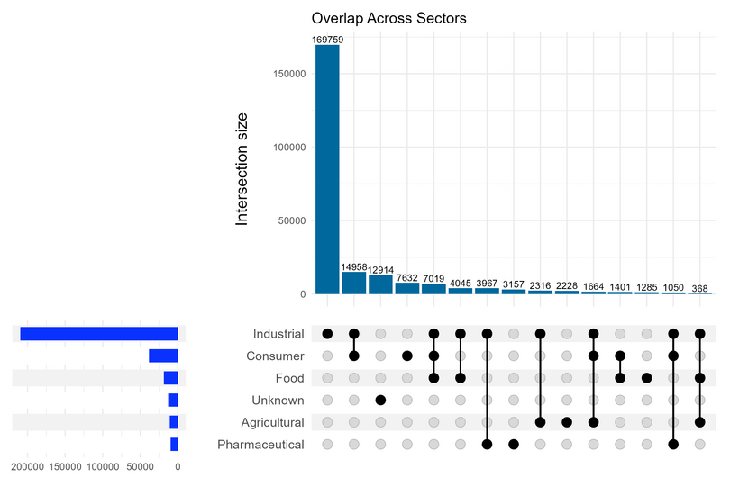

```r
#============================================================================================================================================
do_sector_plot = function() {

k<-data.frame(cbind(as.logical(rocks_sector_table$consumer),as.logical(rocks_sector_table$food),as.logical(rocks_sector_table$industrial),as.logical(rocks_sector_table$agricultural),as.logical(rocks_sector_table$pharmaceutical)))
colnames(k)<-c("Consumer","Food","Industrial","Agricultural","Pharmaceutical")
#upset(k, intersect=c("Consumer","Food","Industrial","Agricultural","Pharmaceutical"))

sum<-rowSums(k)

k$Unknown<-FALSE
k$Unknown[which(sum==0)]<-TRUE

p <- upset(
 # k[sum > 0, ],
  k,
  intersect = c("Consumer", "Food", "Industrial", "Agricultural", "Pharmaceutical", "Unknown"),
  max_degree = 3,
  min_size = 200,
  sort_intersections_by = "cardinality",
  width_ratio = 0.3,

  base_annotations = list(
    "Intersection size" = intersection_size(
      counts = TRUE,
      bar_number_threshold = Inf,   # <- prevents labels being moved inside bars
      text = list(colour = "black",
                  size=3
      ),
      mapping = aes(fill = "All")
    ) +
      scale_fill_manual(values = c("All" = ULcolors[4]), guide = "none") +
      ylab("Intersection size")+labs(title = "Overlap Across Sectors") +
      theme(axis.title.y = element_text(size = 14,vjust=-10))
  ),

  set_sizes = upset_set_size(
    mapping = aes(fill = "All")
  ) +
    scale_fill_manual(values = c("All" = ULcolors[3]), guide = "none") +
    theme(
      axis.title.x = element_blank(),
      axis.title.y = element_blank()
    ),
  matrix = intersection_matrix() +
    labs(x = NULL, y = NULL) +
    theme(
      axis.title.x = element_blank(),
      axis.title.y = element_blank()
    )
) +
  theme_minimal(base_size = 14) +
  theme(
    panel.grid.major.x = element_blank(),
    panel.grid.minor = element_blank(),
    axis.text.x = element_blank(),
    axis.ticks.x = element_blank(),
    axis.title.x = element_blank(),
    plot.title = element_text(face = "bold"),
    strip.text = element_text(face = "bold", size = 12)
  )

return(p)
}

p<-do_sector_plot()
#write the plot

filename<-"Output/sector_plot.png"
ggsave(filename, plot = p, width = 9, height =6, dpi = 300)

preview_file <- preview_png(filename,
  scale = 0.3
)
knitr::include_graphics(preview_file)
```

INVENTORY PLOT: Figure 1

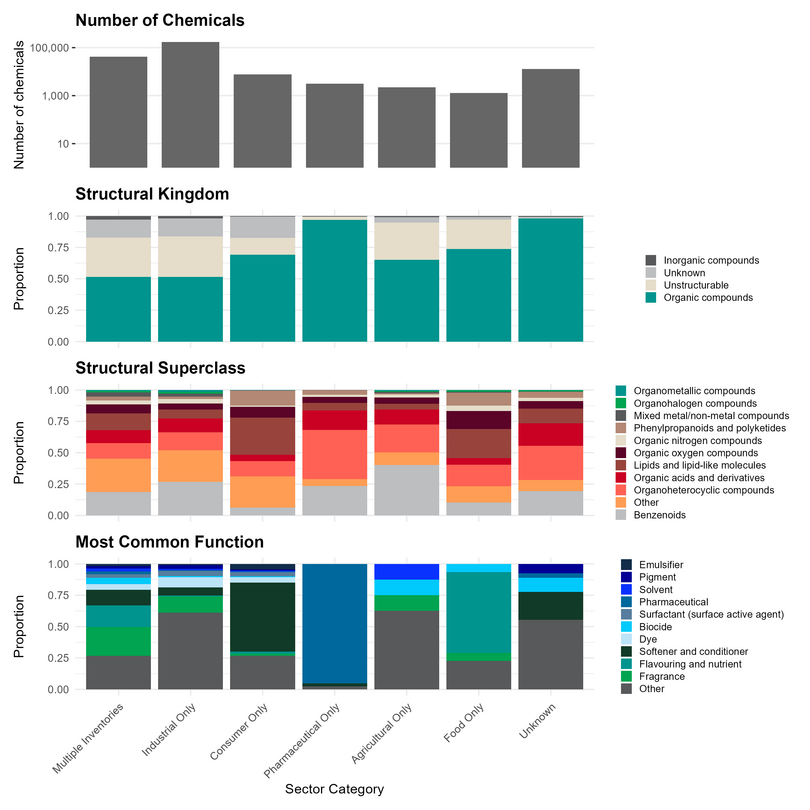

```r
do_inventory_plot = function() {
#Generate the Inventory Plot


#Decide which categories to keep
j<-data.frame(table(inventory_all_descriptors2$most_common_function_category))


base<-inventory_all_descriptors2
keepfunctions<-c("Fragrance","Flavouring and nutrient","Softener and conditioner","Dye","Biocide","Surfactant (surface active agent)","Solvent","Emulsifier","Pharmaceutical","Pigment","Unknown")

base$most_common_function_category<-capitalize_first(base$most_common_function_category)

base$most_common_function_category[which(is.na(base$most_common_function_category))]<-"Unknown"
base$most_common_function_category[which(base$most_common_function_category=="NANA")]<-"Unknown"

base$most_common_function_category[which(!base$most_common_function_category %in% keepfunctions)]<-"Other"

j<-data.frame(table(base$superclass))
keepclasses<-c("Benzenoids","Organoheterocyclic compounds","Organic acids and derivatives","Lipids and lipid-like molecules","Organic oxygen compounds","Mixed metal/non-metal compounds","Organic nitrogen compounds","Phenylpropanoids and polyketides","Organohalogen compounds","Organometallic compounds","UVCB", "unknown")
base$superclass[which(!base$superclass %in% keepclasses)]<-"Other"

#  Long format
# ----------------------------
long_dt <- data.table::melt(
  data.table(base),
  id.vars = "inventory_type",
  measure.vars = c("most_common_function_category", "sector_class", "kingdom", "superclass"),
  variable.name = "category_type",
  value.name = "category_value"
)

#remove things we don't want to plot
long_dt<-long_dt[which(!(category_value=="Unknown" & category_type %in% c("most_common_function_category"))),]
long_dt<-long_dt[which(!(category_value=="UVCB" & category_type %in% c("superclass"))),]


# Explicit Missing
invisible({
  long_dt[is.na(category_value), category_value := "Missing"]
  long_dt[is.na(inventory_type), inventory_type := "Missing"]
})

# ----------------------------
# 4. Plot function (fully fixed)
# ----------------------------
make_plot <- function(varname,
                      base_colors,
                      title = NULL,
                      show_y = TRUE,
                      show_x = TRUE, type="inventory") {

  sub_dt <- copy(long_dt[category_type == varname])

  # Order categories globally (Missing first ⇒ plotted on top)
  freq <- sub_dt[, .N, by = category_value][order(N)]
  if ("Missing" %in% freq$category_value) {
    levels_order <- c("Missing", setdiff(freq$category_value, "Missing"))
  } else {
    levels_order <- freq$category_value
  }
  sub_dt[, category_value := factor(category_value, levels = levels_order)]

  # Build safe color vector
  cats <- levels(sub_dt$category_value)
  col_vec <- rep(base_colors, length.out = length(cats))
  names(col_vec) <- cats
  col_vec["Missing"] <- "#B0B0B0"

  p <- ggplot(sub_dt, aes(x = inventory_type, fill = category_value)) +
    geom_bar(position = "fill") +
    scale_fill_manual(values = col_vec, drop = FALSE) +
    labs(
      title = ifelse(is.null(title), varname, title),
      x = if (show_x) "Sector Category" else NULL,
      y = if (show_y) "Proportion" else NULL,
      fill = varname
    ) +
    theme_minimal() +
    theme(
      legend.title = element_blank(),
      plot.title = element_text(face = "bold"),
      axis.text.x = element_text(angle = 45, hjust = 1),
      legend.text = element_text(size = 8),
      legend.key.size = unit(0.35, "cm")
    )

  # Remove axes if requested
  if (!show_y) {
    p <- p + theme(
      axis.text.y = element_blank(),
      axis.ticks.y = element_blank()
    )
  }

  if (!show_x) {
    p <- p + theme(
      axis.text.x = element_blank(),
      axis.ticks.x = element_blank()
    )
  }

  return(p)
}

#By Sector

tmp <- base
tmp$inventory_type <- tmp$sector_class

long_dt <- data.table::melt(
  data.table(tmp),
  id.vars = "inventory_type",
  measure.vars = c("most_common_function_category", "kingdom", "superclass"),
  variable.name = "category_type",
  value.name = "category_value"
)

# remove things we don't want to plot
long_dt <- long_dt[
  !(category_value == "Unknown" & category_type == "most_common_function_category")
]
long_dt <- long_dt[
  !(category_value == "UVCB" & category_type == "superclass")
]

# Explicit Missing
invisible({
  long_dt[is.na(category_value), category_value := "Missing"]
  long_dt[is.na(inventory_type), inventory_type := "Missing"]
})

# force common x order across all panels
sector_order <- unique(long_dt$inventory_type)
sector_order<-  c("Multiple Inventories","Industrial Only","Consumer Only","Pharmaceutical Only","Agricultural Only","Food Only","Unknown")
long_dt[, inventory_type := factor(inventory_type, levels = sector_order)]

# counts per sector_class for aligned bar panel
count_dt <- as.data.table(base)
count_dt[is.na(sector_class), sector_class := "Missing"]
count_dt <- count_dt[, .(n_chemicals = .N), by = sector_class]
count_dt[, sector_class := factor(sector_class, levels = sector_order)]

# horizontal panel with bars aligned to same x positions

library(scales)

p2 <- ggplot(count_dt, aes(x = sector_class, y = n_chemicals)) +
  geom_col(fill = "grey40", width = 0.8) +
  scale_x_discrete(limits = sector_order, drop = FALSE) +
  scale_y_log10(labels = label_comma()) +
  labs(
    x = NULL,
    y = "Number of chemicals",
    title = "Number of Chemicals"
  ) +
  theme_bw() +
  theme(
    plot.title = element_text(face = "bold"),
    axis.text.x = element_blank(),
    axis.ticks.x = element_blank(),
    panel.grid.major.x = element_blank(),
    panel.grid.minor = element_blank(),
    panel.border = element_blank(),
    panel.background = element_blank(),
    plot.background = element_blank(),
    axis.line = element_blank()
  )
kingdomcols<-c(inorgcolor,strucunknown,unstructcolor,orgcolor)
p1 <- make_plot("most_common_function_category", ULcolors, show_x = TRUE, title = "Most Common Function")
p3 <- make_plot("kingdom", kingdomcols, show_x = FALSE, title = "Structural Kingdom")
p4 <- make_plot("superclass", ULcolors[9:19], show_x = FALSE, title = "Structural Superclass")

final_plot <-  p2/p3 / p4 /  p1

return(final_plot)
}


filename<-"Output/inventory_panels_fig1.png"
final_plot<-do_inventory_plot()
ggsave(
  filename = filename,
  plot = final_plot,
  width = 9,
  height = 9,
  dpi = 300
)

preview_file <- preview_png(filename,
  scale = 0.3
)
knitr::include_graphics(preview_file)
```

Supplemental Table 3: Inventory counts

```r
files<-list.files("Data/categories", pattern = "rocks_sector_table.*\\.RData$", full.names = TRUE)
file <- files[order(file.info(files)$mtime, decreasing = TRUE)][1]  # Get the most recent

load(file)

j1<-data.frame(table(rocks_sector_table$sector_class))
j1$Variable<-"sector class"
j1$Value<-j1$Var1
j1$Count<-j1$Freq
j1<-j1[,c("Variable","Value","Count")]
j1<-j1[order(-j1$Count),]
j1$Value[which(j1$Value=="NANA")]<-"None"
k1<-c("sector","industrial",length(which(rocks_sector_table$industrial==1)))
k2<-c("sector","food",length(which(rocks_sector_table$food==1)))
k3<-c("sector","consumer",length(which(rocks_sector_table$consumer==1)))
k4<-c("sector","pharmaceutical",length(which(rocks_sector_table$pharmaceutical==1)))
k5<-c("sector","agricultural",length(which(rocks_sector_table$agricultural==1)))
k6<-c("monitoring","biomonitoring",length(which(rocks_sector_table$biomonitoring==1)))
k7<-c("monitoring","environmental",length(which(rocks_sector_table$env_monitoring==1)))

k<-data.frame(rbind(k1,k3,k2,k5,k4,k6,k7))
colnames(k)<-c("Variable","Value","Count")
k$Count<-as.numeric(as.character(k$Count))

#function table
j2<-data.frame(table(inventory_all_descriptors2$most_common_function_category))
j2$Variable<-"most common function"
j2$Value<-j2$Var1
j2$Count<-j2$Freq
j2<-j2[,c("Variable","Value","Count")]
j2<-j2[order(-j2$Count),]
j2$Value<-as.character(j2$Value)
j2$Value[which(j2$Value=="NANA")]<-"None Available"

#region table
j3<-data.frame(table(inventory_all_descriptors2$region_class))
j3$Variable<-"region class"
j3$Value<-j3$Var1
j3$Count<-j3$Freq
j3<-j3[,c("Variable","Value","Count")]
j3<-j3[order(-j3$Count),]
j3$Value<-as.character(j3$Value)


j4<-data.frame(table(inventory_all_descriptors2$superclass))
j4$Variable<-"superclass"
j4$Value<-j4$Var1
j4$Count<-j4$Freq
j4<-j4[,c("Variable","Value","Count")]
j4<-j4[order(-j4$Count),]
j4$Value<-as.character(j4$Value)
j4$Value[which(j4$Value=="UVCB")]<-"Unstructurable"
j4$Value[which(j4$Value=="")]<-"No Classyfire Available"


j<-bind_rows(j1,k,j2,j3,j4)
print(j)
```

```
##                    Variable                                        Value  Count
## ...1           sector class                              Industrial Only 169759
## ...2           sector class                         Multiple Inventories  41627
## ...3           sector class                                      Unknown  12914
## ...4           sector class                                Consumer Only   7632
## ...5           sector class                          Pharmaceutical Only   3157
## ...6           sector class                            Agricultural Only   2228
## ...7           sector class                                    Food Only   1285
## k1                   sector                                   industrial 209703
## k3                   sector                                     consumer  38325
## k2                   sector                                         food  18477
## k5                   sector                                 agricultural  10810
## k4                   sector                               pharmaceutical   9785
## k6               monitoring                                biomonitoring  28476
## k7               monitoring                                environmental   3263
## ...15  most common function                               None Available 226679
## ...16  most common function                                    Fragrance   2571
## ...17  most common function                      Flavouring and nutrient   1875
## ...18  most common function                     Softener and conditioner   1617
## ...19  most common function                                          Dye    562
## ...20  most common function                                      Biocide    558
## ...21  most common function            Surfactant (surface active agent)    359
## ...22  most common function                               Pharmaceutical    284
## ...23  most common function                                      Solvent    257
## ...24  most common function                                      Pigment    226
## ...25  most common function                                   Emulsifier    220
## ...26  most common function                                  Antioxidant    209
## ...27  most common function                                  Plasticizer    190
## ...28  most common function                                     Catalyst    185
## ...29  most common function                                       Binder    177
## ...30  most common function                  Chemical reaction regulator    164
## ...31  most common function                                    Humectant    150
## ...32  most common function                              Flame retardant    147
## ...33  most common function                   Adhesion/cohesion promoter    139
## ...34  most common function                                Uv stabilizer    132
## ...35  most common function      Processing aids not otherwise specified    118
## ...36  most common function                                 Preservative    116
## ...37  most common function                           Degradant/impurity    112
## ...38  most common function               No specific technical function    104
## ...39  most common function                              Chelating agent     95
```

[output cut: 85 more lines]

```
## ...125           superclass                                 Hydrocarbons   1512
## ...126           superclass                    Alkaloids and derivatives    965
## ...127           superclass      Nucleosides, nucleotides, and analogues    921
## ...128           superclass                                Organic salts    722
## ...129           superclass                   Organophosphorus compounds    597
## ...130           superclass              Homogeneous non-metal compounds    443
## ...131           superclass                Organic 1,3-dipolar compounds    297
## ...132           superclass                  Homogeneous metal compounds    245
## ...133           superclass    Lignans, neolignans and related compounds    184
## ...134           superclass                             Organic Polymers    158
## ...135           superclass                      Hydrocarbon derivatives    111
## ...136           superclass                                   Acetylides     71
## ...137           superclass                              Inorganic salts     27
## ...138           superclass            Miscellaneous inorganic compounds     11
## ...139           superclass                                      Allenes      4
```

```r
write.csv(j,"Output/inventory_counts_SI_TableS3.csv",row.names=FALSE)
```

Sector Mapping: Figure 2

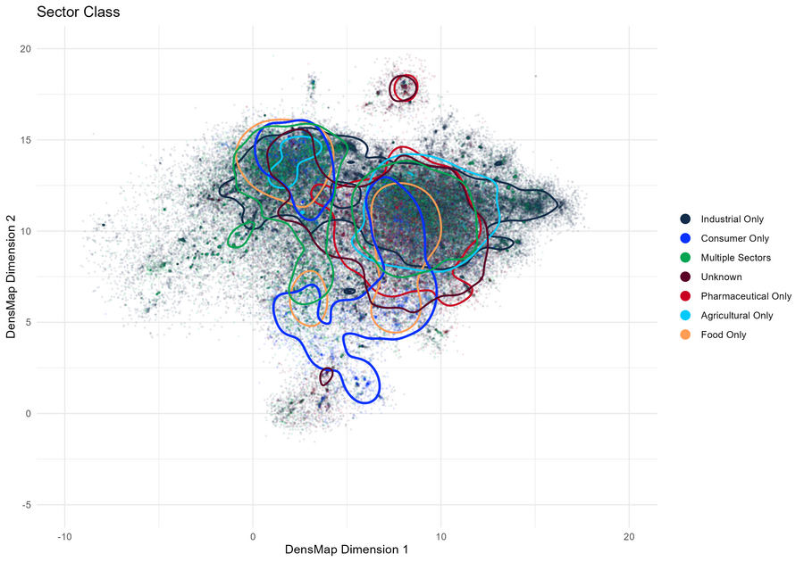

```r
do_sector_mapping<- function() {
j<-fingerprints

#merge
tmp<-left_join(inventory_all_descriptors2, j, by=c("cichem_id"="cichem"))

tmp<-tmp[which(!is.na(tmp$densmap_1)),] #structurable

#make a ggplot scatter of tnse1 vs tsne2 colored by sector class
set.seed(125)
colors<-sample(ULcolors, length(unique(tmp$sector_class)), replace = FALSE)
library(ggplot2)
#order the levels of sector

tmp$sector_class[tmp$sector_class=="Multiple Inventories"]<-"Multiple Sectors"
tmp$sector_class <- factor(tmp$sector_class, levels = c("Industrial Only","Consumer Only","Multiple Sectors","Unknown","Pharmaceutical Only","Agricultural Only" ,"Food Only" ))

colors<-c("Industrial Only"= ind_color,"Consumer Only"= consumer_color,"Multiple Sectors"= multiple_color,"Unknown"= unknown_color,"Pharmaceutical Only"=pharma_color,"Agricultural Only" = ag_color,
"Food Only" = food_color)

# count points per sector
group_sizes <- table(tmp$sector_class)

# add size to data
tmp$group_size <- group_sizes[as.character(tmp$sector_class)]

# sort largest groups first
tmp <- tmp[order(-tmp$group_size), ]

sectordensity <- ggplot(
  tmp,
  aes(x = densmap_1, y = densmap_2, color = sector_class)) +
  geom_point(alpha = 0.1, size=0.6, shape=16) +
  theme_minimal() +
  labs(title = "Sector Class") +xlab("DensMap Dimension 1")+ ylab("DensMap Dimension 2")+
  scale_color_manual(values = colors) +
  theme(legend.title = element_blank())+ guides(color = guide_legend(override.aes = list(size = 4, alpha = 1)))


quantiles = c(0.50, 0.75, 0.90)
quantiles = c(0.70)


flag_cols <- c( "pharma_only","industrial_only","unknown","food_only","multiple","ag_only","consumer_only","pharmaceutical","agricultural","consumer","food","industrial")
# for (name in flag_cols) {
#   densname<-paste0("dens_", gsub(" ", "_", tolower(name)))
#   density_result <- get(densname)
#   cont <- estimate_density_contours(
#     density_result = density_result,
#     density_quantiles = quantiles
#   )
#   assign(paste0("cont_", name), cont)
# }


for (name in flag_cols) {
  densname<-paste0("dens_", gsub(" ", "_", tolower(name)))
  density_result <- get(densname)
  cont <- estimate_coverage_contours(
    density_result = density_result,
    coverages = quantiles
  )
  assign(paste0("cont_", name), cont)
}


linew<-0.8
#explore density contours for each sector class
sectordensity1<-sectordensity +   ylim(-5,20)+xlim(-10,20)+
  geom_path(data = cont_pharma_only$contours,aes(x = x,y = y,group = contour_id),color = pharma_color,linewidth = linew,inherit.aes = FALSE)+
  geom_path(data = cont_industrial_only$contours,aes(x = x,y = y,group = contour_id),color = ind_color,linewidth =linew,inherit.aes=FALSE)+
  geom_path(data = cont_food_only$contours,aes(x = x,y = y,group = contour_id),color = food_color,linewidth =linew,inherit.aes=FALSE)+
  geom_path(data = cont_ag_only$contours,aes(x = x,y = y,group = contour_id),color = ag_color,linewidth =linew,inherit.aes=FALSE)+
  geom_path(data = cont_consumer_only$contours,aes(x = x,y = y,group = contour_id),color = consumer_color,linewidth =1,inherit.aes=FALSE)+
  geom_path(data = cont_unknown$contours,aes(x = x,y = y,group = contour_id),color = unknown_color,linewidth =linew,inherit.aes=FALSE)+
  geom_path(data = cont_multiple$contours,aes(x = x,y = y,group = contour_id),color = multiple_color,linewidth =linew,inherit.aes=FALSE)


sectordensity2<-sectordensity +  ylim(-5,20)+xlim(-10,20)+
  geom_path(data = cont_pharmaceutical$contours,aes(x = x,y = y,group = contour_id),color = pharma_color,linewidth = linew,inherit.aes = FALSE)+
  geom_path(data = cont_industrial$contours,aes(x = x,y = y,group = contour_id),color = ind_color,linewidth =linew,inherit.aes=FALSE)+
  geom_path(data = cont_food$contours,aes(x = x,y = y,group = contour_id),color = food_color,linewidth =linew,inherit.aes=FALSE)+
  geom_path(data = cont_agricultural$contours,aes(x = x,y = y,group = contour_id),color = ag_color,linewidth =linew,inherit.aes=FALSE)+
  geom_path(data = cont_consumer$contours,aes(x = x,y = y,group = contour_id),color = consumer_color,linewidth =1,inherit.aes=FALSE)+
  geom_path(data = cont_unknown$contours,aes(x = x,y = y,group = contour_id),color = unknown_color,linewidth =linew,inherit.aes=FALSE)


  #a little transparent
return(  list(
    plot1 = sectordensity1,
    plot2 = sectordensity2
  ))
}
k<-do_sector_mapping()
filename<-"Output/sector_mapping1.png"
ggsave(
  filename = filename,
  plot = k[[1]],
  width = 10,
  height = 7,
  dpi = 300
)
preview_file <- preview_png(filename,
  scale = 0.3
)
knitr::include_graphics(preview_file)
```

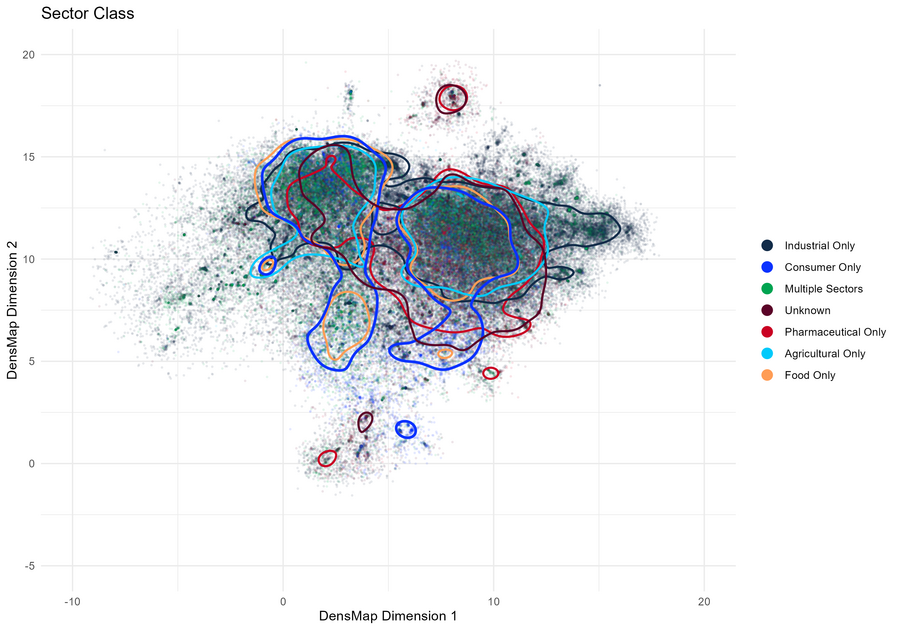

```r
filename<-"Output/sector_mapping2.png"
ggsave(
  filename = filename,
  plot = k[[2]],
  width = 10,
  height = 7,
  dpi = 300
)
preview_file <- preview_png(filename,
  scale = 0.3
)
knitr::include_graphics(preview_file)
```

Generate Table of Use and Emission by Structurable vs. Unstructurable: SI Table 4.

```r
#load latest version of inventory_use data_DATE

file<-list.files("Data", pattern = "inventory_use_data.*\\.RData$", full.names = TRUE)
file <- file[order(file.info(file)$mtime, decreasing = TRUE)][1]  # Get the most recent file
load(file)

inventory_use$kingdom[which(inventory_use$kingdom=="UVCB")]<-"Unstructurable"
tmp<-inventory_use[which(inventory_use$kingdom != c("Unknown")),]

file<-list.files("Data", pattern = "inventory_emission_data.*\\.RData$", full.names = TRUE)
file <- file[order(file.info(file)$mtime, decreasing = TRUE)][1]  # Get the most recent file
load(file)

usedata<-left_join(tmp, inventory_emission)
```

```
## inventory_industrial, inventory_agricultural, inventory_biomonitoring,
## inventory_environmental, inventory_pharmaceutical, sector_class, kingdom)`
```

```r
j<-inventory_all_descriptors2

empiricalusevars<-c("consumer_ciexpo","reported_function_ciexpo","inventory_product","inventory_industry","lp_ciexpo")

rows<-j$cichem_id
nrows<-length(rows)
countwithempiricaluse<-length(which(rowSums(usedata[, empiricalusevars], na.rm = TRUE)>0))
countwithpredicteduse<-length(which(usedata[, c("predicted_function_ciexpo")]==1))
k0<-c("All Chemicals","Use",round(countwithempiricaluse/nrows,3),round(countwithpredicteduse/nrows,3))

rows<-j$cichem_id[which(j$kingdom=="Organic compounds")]
nrows<-length(rows)
countwithempiricaluse<-length(which(rowSums(usedata[usedata$cichem_id %in% rows, empiricalusevars], na.rm = TRUE)>0))
countwithpredicteduse<-length(which(usedata[usedata$cichem_id %in% rows, c("predicted_function_ciexpo")]==1))
k1<-c("Organic compounds","Use",round(countwithempiricaluse/nrows,3),round(countwithpredicteduse/nrows,3))

rows<-j$cichem_id[which(j$kingdom=="Inorganic compounds")]
nrows<-length(rows)
countwithempiricaluse<-length(which(rowSums(usedata[usedata$cichem_id %in% rows, empiricalusevars], na.rm = TRUE)>0))
countwithpredicteduse<-length(which(usedata[usedata$cichem_id %in% rows, c("predicted_function_ciexpo")]==1))
k2<-c("Inorganic compounds","Use",round(countwithempiricaluse/nrows,3),round(countwithpredicteduse/nrows,3))

rows<-j$cichem_id[which(!j$kingdom %in% c("Unstructurable"))]
nrows<-length(rows)
countwithempiricaluse<-length(which(rowSums(usedata[usedata$cichem_id %in% rows, empiricalusevars], na.rm = TRUE)>0))
countwithpredicteduse<-length(which(usedata[usedata$cichem_id %in% rows, c("predicted_function_ciexpo")]==1))
k3<-c("Structurable chemicals","Use",round(countwithempiricaluse/nrows,3),round(countwithpredicteduse/nrows,3))

rows<-j$cichem_id[which(j$kingdom=="Unstructurable")]
nrows<-length(rows)
countwithempiricaluse<-length(which(rowSums(usedata[usedata$cichem_id %in% rows, empiricalusevars], na.rm = TRUE)>0))
countwithpredicteduse<-length(which(usedata[usedata$cichem_id %in% rows, c("predicted_function_ciexpo")]==1))
k4<-c("Unstructurable chemicals","Use",round(countwithempiricaluse/nrows,3),round(0,3))

#Emission

empiricalemvars<-c("inventory_emission")

rows<-j$cichem_id
nrows<-length(rows)
countwithempiricalemission<-length(which(usedata[usedata$cichem_id %in% rows, c("inventory_emission")]==1))
countwithpredictedemission<-length(which(usedata[, c("predicted_emission")]==1))
k5<-c("All Chemicals","Emission",round(countwithempiricalemission/nrows,3),round(countwithpredictedemission/nrows,3))

rows<-j$cichem_id[which(j$kingdom=="Organic compounds")]
nrows<-length(rows)
countwithempiricalemission<-length(which(usedata[usedata$cichem_id %in% rows, c("inventory_emission")]==1))
countwithpredictedemission<-length(which(usedata[usedata$cichem_id %in% rows, c("predicted_emission")]==1))
k6<-c("Organic compounds","Emission",round(countwithempiricalemission/nrows,3),round(countwithpredictedemission/nrows,3))

rows<-j$cichem_id[which(j$kingdom=="Inorganic compounds")]
nrows<-length(rows)
countwithempiricalemission<-length(which(usedata[usedata$cichem_id %in% rows, c("inventory_emission")]==1))
countwithpredictedemission<-length(which(usedata[usedata$cichem_id %in% rows, c("predicted_emission")]==1))
k7<-c("Inorganic compounds","Emission",round(countwithempiricalemission/nrows,3),round(countwithpredictedemission/nrows,3))

rows<-j$cichem_id[which(!j$kingdom %in% c("Unstructurable"))]
nrows<-length(rows)
countwithempiricalemission<-length(which(usedata[usedata$cichem_id %in% rows, c("inventory_emission")]==1))
# countwithempiricalemission<-length(which(rowSums(usedata[usedata$cichem_id %in% rows, empiricalemvars], na.rm = TRUE)>0))
countwithpredictedemission<-length(which(usedata[usedata$cichem_id %in% rows, c("predicted_emission")]==1))
k8<-c("Structurable chemicals","Emission",round(countwithempiricalemission/nrows,3),round(countwithpredictedemission/nrows,3))

rows<-j$cichem_id[which(j$kingdom=="Unstructurable")]
nrows<-length(rows)
countwithempiricalemission<-length(which(usedata[usedata$cichem_id %in% rows, c("inventory_emission")]==1))
countwithpredictedemission<-length(which(usedata[usedata$cichem_id %in% rows, c("predicted_emission")]==1))
k9<-c("Unstructurable chemicals","Emission",round(countwithempiricalemission/nrows,3),round(countwithpredictedemission/nrows,3))

k<-rbind(k0,k1,k2,k3,k4,k5,k6,k7,k8,k9)
colnames(k)<-c("Group","Domain","Fraction with Empirical Data","Fraction with Predicted Data")
print(k)
```

```
##    Group                      Domain     Fraction with Empirical Data
## k0 "All Chemicals"            "Use"      "0.114"
## k1 "Organic compounds"        "Use"      "0.135"
## k2 "Inorganic compounds"      "Use"      "0.246"
## k3 "Structurable chemicals"   "Use"      "0.113"
## k4 "Unstructurable chemicals" "Use"      "0.118"
## k5 "All Chemicals"            "Emission" "0.002"
## k6 "Organic compounds"        "Emission" "0.004"
## k7 "Inorganic compounds"      "Emission" "0.011"
## k8 "Structurable chemicals"   "Emission" "0.003"
## k9 "Unstructurable chemicals" "Emission" "0"
##    Fraction with Predicted Data
## k0 "0.483"
## k1 "0.84"
## k2 "0.87"
## k3 "0.682"
## k4 "0"
## k5 "0.016"
## k6 "0.029"
## k7 "0.003"
## k8 "0.023"
## k9 "0"
```

```r
write.csv(k,"Output/use_emission_coverage.csv",row.names = F)
```

FUNCTION ANALYSES

```r
#how many inventory chemicals had functions

load("data/inventory_all_descriptors2.Rdata")

num_had_func<-length(which(inventory_all_descriptors2$most_common_function_category!="NANA" & inventory_all_descriptors2$most_common_function_category!=""))

print(paste0("Number of chemicals with reported functional use: ",num_had_func," ",num_had_func/length(inventory_all_descriptors2$cichem_id)))
```

```
## [1] "Number of chemicals with reported functional use: 11923 0.0499702433340877"
```

```r
#look at reported functional uses of REACH chemicals that were reported as "intermediate only"
load("Data/reach/reach_data_final.Rdata")

#get predicted_functional_use
load("Data/function_use.Rdata")

#highly predicted function is >0.8
function_use_high<-function_use[which(function_use$probability>0.8),]

intermediates<-unique(reach_data_final[which(reach_data_final$Total.tonnage.Band=="Intermediate use only"),c("cichem_id","Total.tonnage.Band")])


industrial_only<-unique(inventory_all_descriptors2[which(inventory_all_descriptors2$sector_class=="Industrial Only"),c("cichem_id","sector_class")])

#how intermediates from REACH had predicted and reported functional uses
intermediates1<-left_join(intermediates,function_use_high,by=c("cichem_id"="cichem_id"))

print(paste0("Number of Reach Intermediates in Industrial Only collection chemicals= ",length(which(intermediates1$cichem_id %in% industrial_only$cichem_id))))
```

```
## [1] "Number of Reach Intermediates in Industrial Only collection chemicals= 4207"
```

```r
intermediates_with_qsur<-length(unique(intermediates1$cichem_id[which(!is.na(intermediates1$id))]))
perc_has_qsur<-intermediates_with_qsur/length(unique(intermediates1$cichem_id))

intermediates2<-left_join(intermediates, inventory_all_descriptors2)
perc_has_reported<-length(which(intermediates2$most_common_function_category!="NANA" & intermediates2$most_common_function_category!=""))/length(intermediates2$cichem_id)

paste0("Percent of REACH Intermediates without Predicted Functional Use >0.8= ",100-round(perc_has_qsur*100,2),"%")
```

```
## [1] "Percent of REACH Intermediates without Predicted Functional Use >0.8= 56.83%"
```

```r
paste0("Percent of REACH Intermediates without Reported Functional Use= ",100-round(perc_has_reported*100,2),"%")
```

```
## [1] "Percent of REACH Intermediates without Reported Functional Use= 89.34%"
```

```r
#how many industrial only chemicals had function
numreported<-length(which(!is.na(inventory_all_descriptors2$most_common_function_category[which(inventory_all_descriptors2$sector_class=="Industrial Only")])))
print(paste0("Number of Industrial Only Chemicals with Reported Functions= ",numreported," ",numreported/length(which(inventory_all_descriptors2$sector_class=="Industrial Only"))))
```

```
## [1] "Number of Industrial Only Chemicals with Reported Functions= 627 0.00369347133288957"
```

```r
withfuncpred<-length(which(inventory_all_descriptors2$cichem_id[which(inventory_all_descriptors2$sector_class=="Industrial Only")] %in% function_use$cichem_id))

withhighpred<-length(which(inventory_all_descriptors2$cichem_id[which(inventory_all_descriptors2$sector_class=="Industrial Only")] %in% function_use_high$cichem_id))

print(paste0("Number of Industrial Only Chemicals with Predicted Functions= ",withfuncpred," ",withfuncpred/length(which(inventory_all_descriptors2$sector_class=="Industrial Only"))))
```

```
## [1] "Number of Industrial Only Chemicals with Predicted Functions= 83548 0.492156527783505"
```

```r
print(paste0("Number of Industrial Only Chemicals with Predicted Functions >0.8= ",withhighpred," ",withhighpred/length(which(inventory_all_descriptors2$sector_class=="Industrial Only"))))
```

```
## [1] "Number of Industrial Only Chemicals with Predicted Functions >0.8= 45546 0.268297998927892"
```

USE - EMISSION LANDSCAPE PLOT: FIG 3

```r
do_uselandscape_plot = function() {
  # Load necessary libraries
  library(ComplexHeatmap)
  library(grid)
  library(circlize)
  library(dplyr)
  library(data.table)


#==================================================
# LOAD DATA
#==================================================

#load latest version of inventory_use data_DATE

file<-list.files("Data", pattern = "inventory_use_data.*\\.RData$", full.names = TRUE)
file <- file[order(file.info(file)$mtime, decreasing = TRUE)][1]  # Get the most recent file
load(file)

inventory_use$kingdom[which(inventory_use$kingdom=="UVCB")]<-"Unstructurable"
tmp<-inventory_use[which(inventory_use$kingdom != c("Unknown")),]

file<-list.files("Data", pattern = "inventory_emission_data.*\\.RData$", full.names = TRUE)
file <- file[order(file.info(file)$mtime, decreasing = TRUE)][1]  # Get the most recent file
load(file)

usedata<-left_join(tmp, inventory_emission)

usedata<-usedata[,c("inventory_production","inventory_emission","predicted_emission","inventory_industry","inventory_product","consumer_ciexpo","lp_ciexpo","predicted_function_ciexpo","reported_function_ciexpo")]



#==================================================
# PREP MATRICES
#==================================================

flag_mat <- as.matrix(usedata)
storage.mode(flag_mat) <- "numeric"

# grouping factor for all combinations
grp <- interaction(
  tmp$sector_class,
  tmp$kingdom,
  drop = TRUE,
  lex.order = TRUE
)

# counts of 1s by group and variable
count_mat <- rowsum(flag_mat, grp, na.rm = TRUE)
count_mat <- as.matrix(count_mat)

# counts across all chemicals for each original variable
count_chems <- colSums(flag_mat, na.rm = TRUE)

# number of chemicals in each group
group_n <- as.vector(table(grp)[rownames(count_mat)])

# proportion of 1s within each group
prop_mat <- sweep(count_mat, 1, group_n, "/")
prop_mat <- as.matrix(prop_mat)

# split group labels back out
group_vars <- do.call(
  rbind,
  strsplit(rownames(prop_mat), split = "\\.")
) |>
  as.data.frame(stringsAsFactors = FALSE)

colnames(group_vars) <- c("sector_class", "kingdom")

# clamp proportions to [0,1]
fill_prop <- pmin(pmax(prop_mat, 0), 1)

#==================================================
# TOTAL CHEMICALS IN GROUP (ONES + ZEROS)
#==================================================

total_group_mat <- matrix(
  group_n,
  nrow = nrow(prop_mat),
  ncol = ncol(prop_mat),
  byrow = FALSE,
  dimnames = dimnames(prop_mat)
)

#==================================================
# FLIP / ROTATE FOR DISPLAY
#==================================================

# After transpose:
# - original variables become rows
# - original groups become columns
prop_mat_t        <- t(prop_mat)
fill_prop_t       <- t(fill_prop)
count_mat_t       <- t(count_mat)
total_group_mat_t <- t(total_group_mat)


#==================================================
# PRETTY ROW LABELS (INSERT HERE)
#==================================================

new_row_names <- rownames(prop_mat_t)


# manual overrides (EDIT THESE) Order doesnt matter (matched belwo)
pretty_row_labels <- c(
  "inventory_product"     = "Product Category (Inventory)",
  "inventory_industry"   = "Industrial Category (Inventory)",
  "reported_function_ciexpo"         = "Function (CIExpo-Use)",
  "lp_ciexpo" = "General Use (CIExpo-Use)",
  "predicted_function_ciexpo" = "Predicted Function",
  "consumer_ciexpo" = "Product Category (CIExpo-Use)",
  "inventory_production" = "Production/Import Volume (Inventory)",
  "inventory_emission" = "Emission Volume (Inventory)",
  "predicted_emission" = "Predicted Emission Volume"
)

idx <- new_row_names %in% names(pretty_row_labels)
new_row_names[idx] <- pretty_row_labels[new_row_names[idx]]

# apply back to ALL matrices used downstream
rownames(prop_mat_t)        <- new_row_names
rownames(fill_prop_t)       <- new_row_names
rownames(count_mat_t)       <- new_row_names
rownames(total_group_mat_t) <- new_row_names


nr <- nrow(prop_mat_t)
nc <- ncol(prop_mat_t)

layout_mat <- matrix(
  0,
  nrow = nr,
  ncol = nc,
  dimnames = list(rownames(prop_mat_t), colnames(prop_mat_t))
)

##Define valid/invalid pies

valid_mat <- matrix(
  TRUE,
  nrow = nrow(prop_mat_t),
  ncol = ncol(prop_mat_t),
  dimnames = dimnames(prop_mat_t)
)

# invalid combinations

valid_mat[
  "Product Category (CIExpo-Use)",
  group_vars$sector_class == "Industrial Only"
] <- FALSE

valid_mat[
  "Predicted Function",
  group_vars$kingdom == "Unstructurable"
] <- FALSE

valid_mat[
  "Product Category (Inventory)",
  group_vars$sector_class == "Industrial Only"
] <- FALSE


valid_mat[
  "Industrial Category (Inventory)",
  group_vars$sector_class %in% c("Consumer Only", "Pharmaceutical Only", "Agricultural Only", "Food Only")
] <- FALSE



fill_prop_t[!valid_mat] <- NA

#==================================================
# FIXED PIE SIZE + BOTTOM ANNOTATION FOR BIN COUNTS
#==================================================

cell_w_mm <- 8
cell_h_mm <- 8

# Fixed pie radius as fraction of smaller cell dimension
pie_r_factor <- 0.45

# Chemical counts to display under each column/bin
# This assumes counts are the same across rows within each column.
# If not, see safety check below.
bin_counts <- total_group_mat_t[1, ]

# Optional safety check: make sure counts are column-level, not row-specific
if (!all(apply(total_group_mat_t, 2, function(z) length(unique(na.omit(z))) <= 1))) {
  warning(
    "total_group_mat_t has different counts across rows within at least one column. ",
    "Using first row for bottom annotation. Check whether this is intended."
  )
}

# Format labels for bottom annotation
bin_count_labels <- formatC(
  bin_counts,
  format = "d",
  big.mark = ","
)

#==================================================
# CATEGORY FOR PIE COLOR (ASSOCIATED WITH ROWS)
#==================================================
# Replace this placeholder with your real row -> category mapping.
# Names must match rownames(prop_mat_t), i.e. the displayed row labels.


#==================================================
# CATEGORY FOR PIE COLOR (ASSOCIATED WITH ROWS)
#==================================================
```

```r
row_category <- c(
  "Product Category (Inventory)"    = "Traditional",
  "Industrial Category (Inventory)" = "Traditional",
  "Production/Import Volume (Inventory)" = "Traditional",
  "Emission Volume (Inventory)" = "Traditional",
  "Function (CIExpo-Use)"           = "NAM",
  "General Use (CIExpo-Use)"        = "NAM",
  "Predicted Function"              = "NAM",
  "Product Category (CIExpo-Use)"   = "NAM",
  "Predicted Emission Volume"       = "NAM"
)

# make sure order matches displayed rows
row_category <- row_category[rownames(prop_mat_t)]

# safety check
if (any(is.na(row_category))) {
  stop("Some row names in prop_mat_t are missing from row_category.")
}

row_category <- as.character(row_category)

row_cat_levels <- unique(row_category)

if (length(row_cat_levels) > length(ULcolors)) {
  stop("Not enough colors in ULcolors for the number of row categories.")
}

# choose 2 colors explicitly
row_cat_cols <- c(
  "Traditional" = tradcolor,
  "NAM"    = namcolor
)


#==================================================
# TOP ANNOTATION COLORS
#==================================================

make_named_palette <- function(values, palette) {
  levs <- unique(as.character(values))

  if (length(levs) > length(palette)) {
    stop("Not enough colors in palette for the number of categories.")
  }

  setNames(palette[seq_along(levs)], levs)
}

sector_cols <- make_named_palette(group_vars$sector_class, ULcolors)
kingdom_cols <- make_named_palette(group_vars$kingdom, ULcolors[c(19,17,7)])

sector_cols<-c("Industrial Only"= ind_color,"Consumer Only"= consumer_color,"Multiple Inventories"= multiple_color,"Unknown"= unknown_color,"Pharmaceutical Only"=pharma_color,"Agricultural Only" = ag_color,
"Food Only" = food_color)

bottom_ha <- HeatmapAnnotation(
  Kingdom = group_vars$kingdom,
  Sector = group_vars$sector_class,
  col = list(
    Sector = sector_cols,
    Kingdom = kingdom_cols
  ),
  show_legend = c(
    sector_class = FALSE,
    kingdom = FALSE
  ),

  show_annotation_name = TRUE,
  annotation_name_side = "left",
  annotation_name_rot = 0,
  annotation_name_gp = gpar(fontsize = 7),
  simple_anno_size = unit(3, "mm"),
  gap = unit(1, "mm")
)


right_ha <- rowAnnotation(
  `Chemicals with Data` = anno_barplot(
    log10(count_chems),
    gp = gpar(fill = "grey40", col = NA),
    border = FALSE,
    width = unit(2, "cm"),
    axis_param = list(
      side = "top",
      at = log10(c(100, 1000, 10000,100000)),
      labels = c("100", "1000","10000","100000")
    )
  ),
  show_annotation_name = TRUE,
  annotation_name_side = "top",
  annotation_name_rot = 0,
  annotation_name_gp = gpar(
    fontsize = 8,
    fontface = "bold"
  )
)


left_ha <- rowAnnotation(
  pie_category = row_category,
  col = list(pie_category = row_cat_cols),
  show_annotation_name = TRUE,
  annotation_name_rot = 90,
  annotation_name_gp = gpar(fontsize = 7),
  simple_anno_size = unit(3, "mm")
)



top_ha <- HeatmapAnnotation(

  N = anno_text(
    format(bin_counts, big.mark = ","),
    location = 0.5,
    just = "center",
    rot = 0,
    gp = gpar(fontsize = 6)
  ),

  `Chemicals in Group` = anno_barplot(
    log10(bin_counts),
    gp = gpar(fill = "grey40", col = NA),
    border = FALSE,
    axis_param = list(
      side = "left",
      at = log10(c(10,100,1000,10000,100000)),
      labels = c("10","100","1000","10000","100000")
    )
  ),

  show_annotation_name = TRUE,
  annotation_name_side = "left",
  annotation_name_rot = 0,
  annotation_name_gp = gpar(fontsize = 8, fontface = "bold"),
  which = "column",

  annotation_height = unit.c(
    unit(4, "mm"),
    unit(20, "mm")
  )
)

#==================================================
# HELPER: DRAW 2-SLICE PIE
#==================================================

draw_pie_cell <- function(x, y, r_mm, prop, fill_col, bg_col = "grey85") {

  if (is.na(prop)) return(NULL)

  prop <- max(min(prop, 1), 0)
  values <- c(prop, 1 - prop)
  fills  <- c(fill_col, bg_col)

  if (sum(values, na.rm = TRUE) == 0) return(NULL)

  pushViewport(viewport(
    x = x,
    y = y,
    width = unit(2 * r_mm, "mm"),
    height = unit(2 * r_mm, "mm"),
    just = c("center", "center")
  ))

  theta <- c(0, cumsum(values) * 2 * pi)

  for (k in 1:2) {
    if (values[k] <= 0) next

    ang <- seq(theta[k], theta[k + 1], length.out = 100)

    xs <- c(0.5, 0.5 + 0.5 * cos(ang), 0.5)
    ys <- c(0.5, 0.5 + 0.5 * sin(ang), 0.5)

    grid.polygon(
      x = unit(xs, "npc"),
      y = unit(ys, "npc"),
      gp = gpar(fill = fills[k], col = NA)
    )
  }

  popViewport()
}

#==================================================
# HEATMAP
#==================================================


ht <- Heatmap(
  layout_mat,
  name = NULL,
  col = c("0" = "white"),
  show_heatmap_legend = FALSE,
  rect_gp = gpar(col = "grey85", fill = NA),
  cluster_rows = FALSE,
  cluster_columns = FALSE,

  show_row_names = TRUE,
  row_names_side = "left",
  row_names_gp = gpar(fontsize = 8),
  show_column_names = FALSE,

  # left_annotation = left_ha,
  top_annotation = top_ha,
  bottom_annotation = bottom_ha,
  right_annotation = right_ha,


  #column_title = "Number of chemicals in group",
  #column_title_side = "bottom",
  #column_title_gp = gpar(fontsize = 8, fontface = "bold"),

  width = unit(nc * cell_w_mm, "mm"),
  height = unit(nr * cell_h_mm, "mm"),

  cell_fun = function(j, i, x, y, width, height, fill) {

    w_mm <- convertWidth(width, "mm", valueOnly = TRUE)
    h_mm <- convertHeight(height, "mm", valueOnly = TRUE)

    # Skip empty or missing cells if needed
    if (is.na(fill_prop_t[i, j])) return(NULL)

    # Fixed pie size
    r_mm <- pie_r_factor * min(w_mm, h_mm)

    draw_pie_cell(
      x = x,
      y = y,
      r_mm = r_mm,
      prop = fill_prop_t[i, j],
      fill_col = row_cat_cols[row_category[i]],
      bg_col = "grey85"
    )
  }
)


#==================================================
# LEGENDS
#==================================================


lgd_rowcat <- Legend(
  title = "Data Type",
  labels = names(row_cat_cols),
  legend_gp = gpar(fill = unname(row_cat_cols), col = NA),
  title_gp = gpar(fontsize = 8),
  labels_gp = gpar(fontsize = 7)
)
```

```r
lgd_sector <- Legend(
  title = "Sector",
  labels = names(sector_cols),
  legend_gp = gpar(fill = unname(sector_cols), col = NA),
  title_gp = gpar(fontsize = 8),
  labels_gp = gpar(fontsize = 7)
)

lgd_kingdom <- Legend(
  title = "Kingdom",
  labels = names(kingdom_cols),
  legend_gp = gpar(fill = unname(kingdom_cols), col = NA),
  title_gp = gpar(fontsize = 8),
  labels_gp = gpar(fontsize = 7)
)

#==================================================
# DRAW TO SCREEN
#==================================================

pd <- packLegend(
  lgd_sector,
  lgd_kingdom,
  lgd_rowcat,
  direction = "horizontal",
  gap = unit(6, "mm")
)

filename<-"Output/uselandscape_fig3.png"
png(filename,
  width = 10,
  height =7,
  units = "in",
  res = 300
)

draw(
  ht,
  heatmap_legend_side = "bottom",
  annotation_legend_side = "bottom",
  annotation_legend_list = list(pd)
)

dev.off()
return(filename)
}


#this handled differently because it is a complex heatmap and not a ggplot object
final_plot<-do_uselandscape_plot()
```

```
## inventory_industrial, inventory_agricultural, inventory_biomonitoring,
## inventory_environmental, inventory_pharmaceutical, sector_class, kingdom)`
```

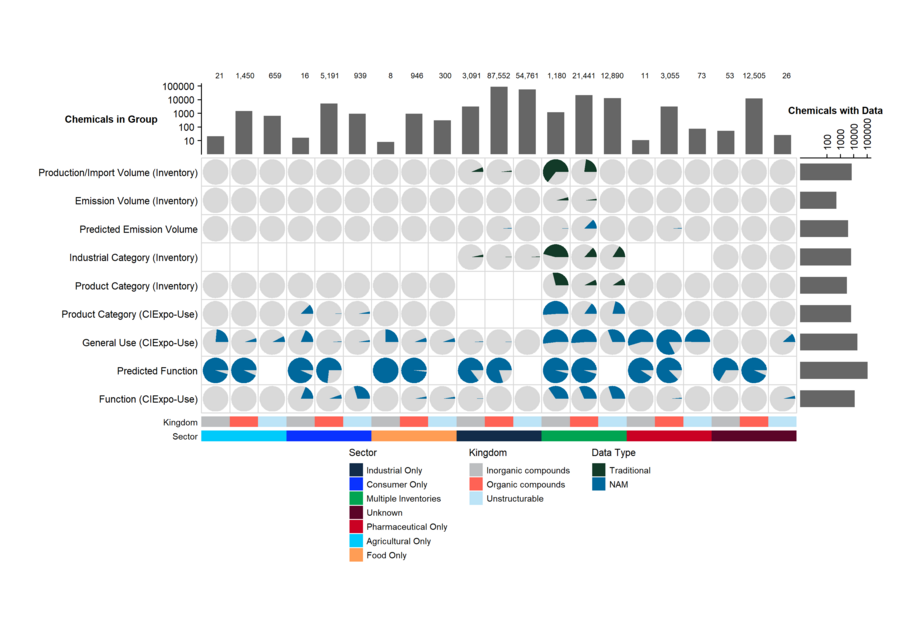

```r
preview_file <- preview_png(final_plot,
  scale = 0.3
)
knitr::include_graphics(preview_file)
```

Function plots in Chemical Space: Supplemental Figure S2

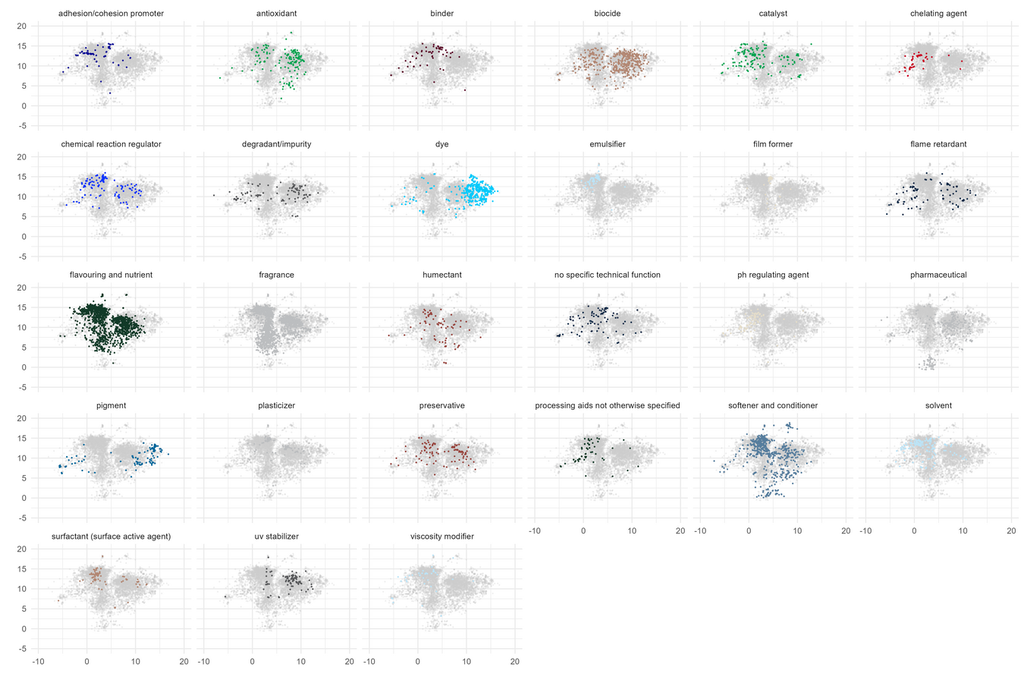

```r
#
#FUNCTION
do_function_plots<- function() {

library(ggplot2)

j<-fingerprints

#merge
#j<-left_join(j,cichemid,by=c("cicomp_id"="cicomp"))
tmp<-left_join(inventory_all_descriptors2, j, by=c("cichem_id"="cichem"))

#Decide which categories to keep

#order the levels of function
funccounts<-data.frame(table(tmp$most_common_function_category))
keepfunctions<-funccounts$Var1[which(funccounts$Freq>200)]

keepfunctions<-keepfunctions[keepfunctions!="NA"]
keepfunctions<-keepfunctions[keepfunctions!="NANA"]
keepfunctions<-keepfunctions[!is.na(keepfunctions)]
keepfunctions<-keepfunctions[keepfunctions!="unknown"]
keepfunctions<-keepfunctions[keepfunctions!="Unknown"]

tmp$most_common_function_category2 <- factor(tmp$most_common_function_category, levels = keepfunctions)

colors<-sample(ULcolors, length(unique(tmp$most_common_function_category2)), replace = TRUE)
tmp2<-tmp[which(tmp$most_common_function_category2!="Unknown"),]
#tmp2<-tmp[which(tmp$most_common_function_category=="Biocide"),]
functiondensity<-ggplot(tmp2, aes(x=densmap_1, y=densmap_2,color=most_common_function_category2)) +
  geom_point(alpha=0.4, size=1, shape=16) +
  theme_minimal() +
  scale_color_manual(values=colors) +
  theme(legend.title = element_blank())+
#scale to max and min x and y
  #ylim(min(tmp2$densmap_2),max(tmp2$densmap_2))+xlim(min(tmp2$densmap_1),max(tmp2$densmap_1))
  ylim(-5,20)+xlim(-10,20)+ guides(color = guide_legend(override.aes = list(size = 4, alpha = 1)))



#do the previous plot but facet on most common function
keepfunctions<-funccounts$Var1[which(funccounts$Freq>80)]

keepfunctions<-keepfunctions[keepfunctions!="NA"]
keepfunctions<-keepfunctions[keepfunctions!="NANA"]
keepfunctions<-keepfunctions[!is.na(keepfunctions)]
keepfunctions<-keepfunctions[keepfunctions!="unknown"]
keepfunctions<-keepfunctions[keepfunctions!="Unknown"]

length(keepfunctions)

tmp$most_common_function_category2 <- factor(tmp$most_common_function_category, levels = keepfunctions)

# set.seed(126)
# colors<-sample(ULcolors, length(unique(tmp$most_common_function_category2)), replace = TRUE)
# functionfacet<-ggplot(tmp[tmp$most_common_function_category2 %in% keepfunctions,], aes(x=densmap_1, y=densmap_2,color=most_common_function_category2)) +
#   geom_point(alpha=1,size=0.5, shape=16) +
#   theme_minimal() +
#   scale_color_manual(values=colors) +
#   theme(legend.title = element_blank())+
#   ylim(-5,20)+xlim(-10,20)+
#   facet_wrap(~most_common_function_category2)
# print(functionfacet)


library(ggplot2)
library(dplyr)
library(tidyr)

set.seed(126)

colors <- sample(
  ULcolors,
  length(keepfunctions),
  replace = TRUE
)

names(colors) <- keepfunctions

tmp_plot <- tmp %>%
  select(densmap_1, densmap_2, most_common_function_category2) %>%
  mutate(
    most_common_function_category2 = as.character(most_common_function_category2)
  )

tmp_facet <- expand_grid(
  facet_function = as.character(keepfunctions),
  tmp_plot
) %>%
  mutate(
    facet_function = as.character(facet_function),
    has_facet_function = most_common_function_category2 == facet_function
  )

functionfacet <- ggplot() +

  geom_point(
    data = tmp_facet %>% filter(!has_facet_function),
    aes(x = densmap_1, y = densmap_2),
    color = "grey80",
    alpha = 0.3,
    size = 0.5,
    shape = 16
  ) +

  geom_point(
    data = tmp_facet %>% filter(has_facet_function),
    aes(
      x = densmap_1,
      y = densmap_2,
      color = facet_function
    ),
    alpha = 1,
    size = 0.5,
    shape = 16
  ) +
  #no x or y labels
  ylab("")+xlab("")+

  scale_color_manual(values = colors) +
  theme_minimal() +
  theme(legend.title = element_blank()) +
  coord_cartesian(
    xlim = c(-10, 20),
    ylim = c(-5, 20)
  ) +
  facet_wrap(~facet_function)+theme(legend.position = "none")


return(  list(
    plot1 = functiondensity,
    plot2 = functionfacet
  ))

}

k<-do_function_plots()
# filename<-"Output/function_structure.png"
# ggsave(
#   filename = filename,
#   plot = k[[1]],
#   width = 13,
#   height = 7,
#   dpi = 300
# )
# preview_file <- preview_png(filename,
#   scale = 0.3
# )
# knitr::include_graphics(preview_file)

filename<-"Output/function_facet.png"
ggsave(
  filename = filename,
  plot = k[[2]],
  width = 15,
  height = 10,
  dpi = 300
)
preview_file <- preview_png(filename,
  scale = 0.3
)
knitr::include_graphics(preview_file)
```

Examine functional use space of “industrial only” chemicals on the inventory with predicted function: Figure S3

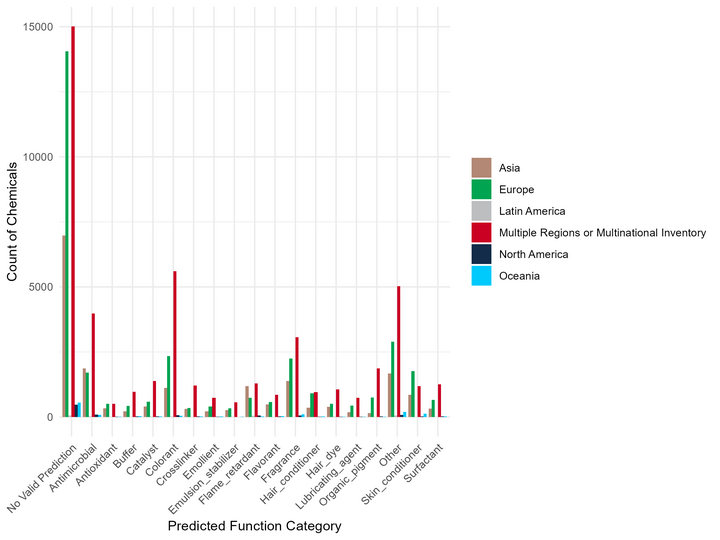

```r
do_function_industrial_only_plot = function() {

load("Data/inventory_all_descriptors2.RData")
load("Data/fingerprints.RData")

j<-fingerprints
tmp<-left_join(inventory_all_descriptors2, j, by=c("cichem_id"="cichem"))

inventory_all_descriptors2$region_class<-NA
sum<- inventory_all_descriptors2$Africa+inventory_all_descriptors2$Asia+inventory_all_descriptors2$Europe+inventory_all_descriptors2$`Latin America`+inventory_all_descriptors2$Oceania+inventory_all_descriptors2$`North America`+inventory_all_descriptors2$Global
inventory_all_descriptors2$region_class[which(inventory_all_descriptors2$Africa==1 & sum==1)]<-"Africa"
inventory_all_descriptors2$region_class[which(inventory_all_descriptors2$Asia==1 & sum==1)]<-"Asia"
inventory_all_descriptors2$region_class[which(inventory_all_descriptors2$Europe==1 & sum==1)]<-"Europe"
inventory_all_descriptors2$region_class[which(inventory_all_descriptors2$`Latin America`==1 & sum==1)]<-"Latin America"
inventory_all_descriptors2$region_class[which(inventory_all_descriptors2$Oceania==1 & sum==1)]<-"Oceania"
inventory_all_descriptors2$region_class[which(inventory_all_descriptors2$`North America`==1 & sum==1)]<-"North America"
inventory_all_descriptors2$region_class[which(inventory_all_descriptors2$Global==1 & sum==1)]<-"Multiple Regions or Multinational Inventory"
inventory_all_descriptors2$region_class[which(sum>1)]<-"Multiple Regions or Multinational Inventory"


#Which Industrial Only chemicals come from different regions
industrial_only<-tmp[which(tmp$sector_class=="Industrial Only"),]
table(industrial_only$region_class)
industrial_only<-industrial_only[which(!is.na(industrial_only$region_class)),]


regioncolors<-c("Asia"=  "#B38874","Europe"=  "#00A451","Latin America"=  "#BCBEC0","North America"="#122C49","Oceania"="#00CAFB", "Multiple Regions or Multinational Inventory"="#CA0123")

# industrialregions<-ggplot(industrial_only, aes(x=densmap_1, y=densmap_2, color=region_class)) +
#   geom_point(alpha=0.8) +
#   theme_minimal() +
#   scale_color_manual(values=regioncolors) +
#   theme(legend.title = element_blank())+  ylim(-5,20)+xlim(-10,20)+
#   facet_wrap(~region_class)
#
# ggsave(
#   filename = "Output/industrial_only_region_landscape.png",
#   plot = industrialregions,
#   width = 15,
#   height = 10,
#   dpi = 300
# )

#look at the predicted function of industrial only chemicals by region

#QSUR values from CIEXPO-Use
load("Data/function_use.RData")

#highly predicted function is >0.5
function_use_high<-function_use[which(function_use$probability>0.8),]

industrial_only_function2<-left_join(industrial_only, function_use_high, by="cichem_id")

#to remove bias, only include cichems that were run through QSUR
industrial_only_function2<-industrial_only_function2[which(industrial_only_function2$cichem_id %in% function_use$cichem_id),]

industrial_only_function2$harmonized_functional_use[which(is.na(industrial_only_function2$harmonized_functional_use))]<-" No Valid Prediction"

#combine for plotting
j2<-data.frame(table(industrial_only_function2$harmonized_functional_use))

#take the top functions as noted by j2$Freq, call rest "Other"

industrial_only_function2$harmonized_functional_use[which(industrial_only_function2$harmonized_functional_use %in% j2$Var1[which(j2$Freq<1000)])]<-"Other"

industrial_only_function2$harmonized_functional_use<-capitalize_first(industrial_only_function2$harmonized_functional_use)

#make a barplot of counts of predicted function by region
library(ggplot2)
funcplot<-ggplot(industrial_only_function2, aes(x=harmonized_functional_use, fill=region_class)) +
  geom_bar(position="dodge") +
  theme_minimal() +
  #labs(title="t-SNE of Chemical Descriptors Colored by Sector Class") +
  scale_fill_manual(values=regioncolors) +
  theme(legend.title = element_blank())+
  xlab("Predicted Function Category") + ylab("Count of Chemicals") +
  theme(axis.text.x = element_text(angle = 45, hjust = 1))
#print(funcplot)


#what about reported functions?
#make a barplot of counts of most common function by region
industrial_only2<-industrial_only[!is.na(industrial_only$most_common_function_category),]
j3<-data.frame(table(industrial_only2$most_common_function_category))

industrial_only2$most_common_function_category[which(industrial_only2$most_common_function_category %in% j3$Var1[which(j3$Freq<10)])]<-"Other"
industrial_only2$most_common_function_category<-capitalize_first(industrial_only2$most_common_function_category)

library(ggplot2)
funcplot2<-ggplot(industrial_only2, aes(x=most_common_function_category, fill=region_class)) +
  geom_bar(position="dodge") +
  theme_minimal() +
  #labs(title="t-SNE of Chemical Descriptors Colored by Sector Class") +
  scale_fill_manual(values=regioncolors) +
  theme(legend.title = element_blank())+
  xlab("Reported Function Category") + ylab("Count of Chemicals") +
  theme(axis.text.x = element_text(angle = 45, hjust = 1))+
  #ADD SPACE ON LEFT FOR LABELS
  theme(plot.margin = unit(c(1,1,1,3), "cm"))

return(  list(
    plot1 = funcplot,
    plot2 = funcplot2
  ))

}


k<-do_function_industrial_only_plot()

filename<-"Output/industrial_only_function_by_region.png"
ggsave(
  filename = filename,
  plot = k[[1]],
  width = 8,
  height = 6,
  dpi = 300
)
preview_file <- preview_png(filename,
  scale = 0.3
)
knitr::include_graphics(preview_file)
```

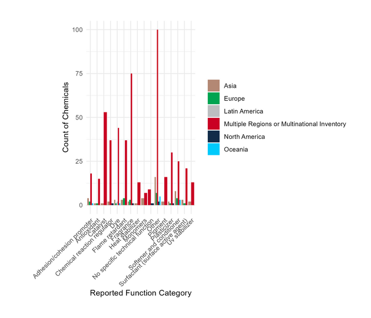

```r
filename<-"Output/industrial_only_reported_function_by_region.png"
ggsave(
  filename = filename,
  plot = k[[2]],
  height = 6,
  dpi = 300
)
preview_file <- preview_png(filename,
  scale = 0.3
)
knitr::include_graphics(preview_file)
```

Monitoring Landscape Visualization: Figure 4

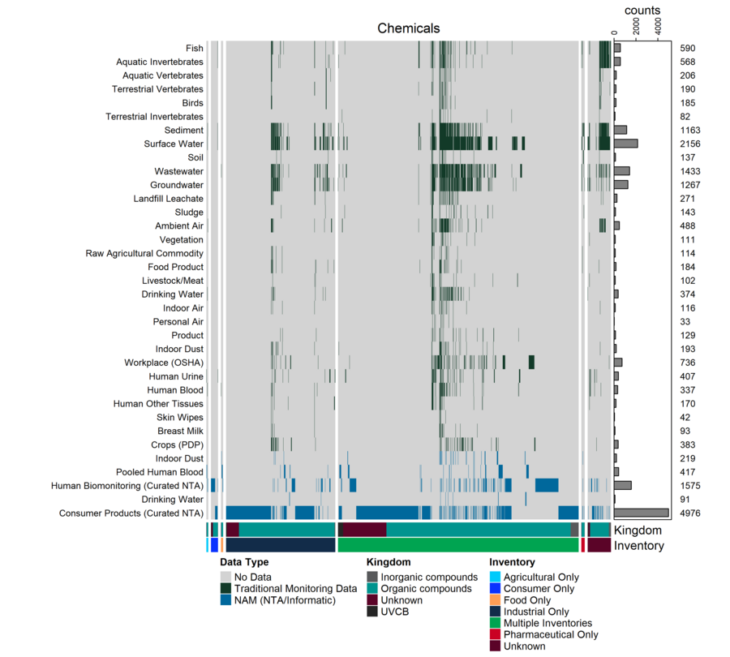

```r
do_monitoring_plot = function() {

  #Monitoring Figure

  load("Data/monitoring_landscape_data_2026-10-12.RData")
  monitoring[is.na(monitoring)]<-0

  #mon<-left_join(monitoring,cichemid, by=c("DTXSID"="dtxsid"))
  mon<-monitoring

  #move cichem_id to first column
  mon<-mon[,c("cichem_id",colnames(mon)[!colnames(mon) %in% c("cichem_id")])]

  mon[is.na(mon)]<-0
  tmp<-mon[3:39]
  k<-colSums(tmp)
  mon<-mon[,!colnames(mon)=="X"]

  mon2<-left_join(mon, inventory_all_descriptors2, by=c("cichem_id"="cichem_id"))

  namestokeep1<-colnames(mon)[!colnames(mon) %in% c("DTXSID","cichem_id","cicomp")]

  mon2<-mon2[which(mon2$cichem %in% inventory_all_descriptors2$cichem),]


  j<-mon2[,colnames(mon2) %in% c(namestokeep1)]
  mon2$sum <- rowSums(j,na.rm = TRUE)
  j<-j[order(mon2$sector_class,mon2$kingdom,-mon2$sum),]
  mon2<-mon2[order(mon2$sector_class,mon2$kingdom),]

  j[] <- lapply(j, function(x) as.character(x) )
  #Traditional Data
  j[j==1]<-"Traditional Monitoring Data"
  j$nontargeted_dust[which(j$nontargeted_dust!=0)]<-"NAM (NTA/Informatic)"
  j$consumer_products[which(j$consumer_products!=0)]<-"NAM (NTA/Informatic)"
  j$nontargeted_drinkingwater[which(j$nontargeted_drinkingwater!=0)]<-"NAM (NTA/Informatic)"
  j$pooled_blood[which(j$pooled_blood!=0)]<-"NAM (NTA/Informatic)"
  j$NTA_biomonitoring_curation[which(j$NTA_biomonitoring_curation!=0)]<-"NAM (NTA/Informatic)"
  #j$BloodExposomeDB[which(j$BloodExposomeDB!=0)]<-"NAM (NTA/Informatic)"

  j[j==0]<-"No Data"


  set1=ULcolors[1:9]

  colors1 = structure(c("#D3D3D3",tradcolor, namcolor), names = c("No Data", "Traditional Monitoring Data", "NAM (NTA/Informatic)"))
  colors2 = ULcolors[c(1:7)]
  colors3 = c("#969696","#636363","#252525","#f7f7f7")
  names(colors2) = unique(mon2$sector_class)
  #update colors
  colors2["Industrial Only"] = ind_color
  colors2["Consumer Only"] = consumer_color
  colors2["Multiple Inventories"] = multiple_color
  colors2["Unknown"] = unknown_color
  colors2["Pharmaceutical Only"] = pharma_color
  colors2["Agricultural Only"] = ag_color
  colors2["Food Only"] = food_color

  names(colors3) = unique(mon2$kingdom)
  colors3["Organic compounds"] = orgcolor
  colors3["Inorganic compounds"] = inorgcolor
  colors3["Unstructurable"] = unstructcolor
  colors3["Unknown"] = unknown_color

  #col_fun = colorRamp2(c(1, 2, 3), c("#D3D3D3",set1[1], set1[2], set1[3]))
  foo = function(x){
    length(which(x!="No Data"))
  }


  #col_fun = colorRamp2(c(1, 2, 3), c("#D3D3D3",set1[1], set1[2], set1[3]))
  foo = function(x){
    length(which(x!="No Data"))
  }

  counts<-sapply(j,foo)


  j<-j[,!colnames(j) %in% c("unknown","precipitation","other.ecological","other.environmental")]


  #reorder
  j<-j[,c("wildlife..fish.","wildlife..aquatic.invertebrate.","wildlife..aquatic.vertebrates.mammals.","wildlife..terrestrial.vertebrates.","wildlife..birds.","wildlife..terrestrial.invertebrates.worms.",
          "sediment","surface.water", "soil", "wastewater..influent..effluent.", "groundwater","landfill.leachate","sludge","ambient.air",
          "vegetation", "raw.agricultural.commodity","food.product", "livestock.meat","drinking.water",
          "indoor.air","personal.air","product","indoor.dust","osha","urine","human.blood..whole.serum.plasma.",
          "human..other.tissues.or.fluids.","skin.wipes","breast.milk","pdp","nontargeted_dust","pooled_blood","NTA_biomonitoring_curation","nontargeted_drinkingwater",
          "consumer_products")]
  counts<-sapply(j,foo)
  collabs<-c(
    "Fish",
    "Aquatic Invertebrates",
    "Aquatic Vertebrates",
    "Terrestrial Vertebrates",
    "Birds",
    "Terrestrial Invertebrates",
    "Sediment",
    "Surface Water",
    "Soil",
    "Wastewater",
    "Groundwater",
    "Landfill Leachate",
    "Sludge",
    "Ambient Air",
    "Vegetation",
    "Raw Agricultural Commodity",
    "Food Product",
    "Livestock/Meat",
    "Drinking Water",
    "Indoor Air",
    "Personal Air",
    "Product",
    "Indoor Dust",
    "Workplace (OSHA)",
    "Human Urine",
    "Human Blood",
    "Human Other Tissues",
    "Skin Wipes",
    "Breast Milk",
    "Crops (PDP)",
    "Indoor Dust",
    "Pooled Human Blood",
    "Human Biomonitoring (Curated NTA)",
    "Drinking Water",
    "Consumer Products (Curated NTA)")

  j_rot<-t(j)
  row.names(j_rot)<-collabs

  #do heat map
  library(ComplexHeatmap)

  width=12
  height=10
  tradcol<-"#ef3b2c"
  ylims=c(1, 5000)
  kingdomvec=rev(mon2$kingdom)
  inventoryvec=rev(mon2$sector_class)
  collabs=collabs
  row_splits=c(1,1,1,1,1,1,2,2,2,4)
  name="Data Type"
  row_title="Data"
  column_title="Chemicals"

  ha_left <- rowAnnotation(
    text = anno_text(
      collabs,
      rot = 0,
      location = unit(1, "npc"),
      just = "right",
      offset = unit(0, "mm"),
      gp = gpar(fontsize = 9),
      width = max_text_width(collabs)
    )
  )

  ## ---- right-side annotation (was top annotation) ----

  mediacat<-c(rep("Wildlife",6),rep("Environmental",9),rep("Dietary",4),rep("Indoor",5),rep("Biomonitoring",5),rep("NTA",4))
  mediacat<-factor(mediacat, levels=c("Wildlife","Environmental","Dietary","Indoor","Biomonitoring","NTA"))

  ha_right <- rowAnnotation(
    counts = anno_barplot(
      counts,
      ylim = ylims,
      add_numbers = FALSE,
      width = unit(2, "cm"),
      axis_param = list(side = "top")
    ),
    counts2 = anno_text(
      counts,
      rot = 0,
      just = "left",
      location = 0,
      gp = gpar(fontsize = 9),
      width = max_text_width(as.character(counts)) + unit(6, "mm")
    ),
    gap = unit(3, "mm"),
    annotation_name_side = "top"
  )

  ha_bottom <- HeatmapAnnotation(
    Kingdom = kingdomvec,
    Inventory = inventoryvec,
    col = list(
      Kingdom = colors3,
      Inventory = colors2
    ),
    which = "column"
  )

  k2 <- Heatmap(
    j_rot,
    show_column_names = FALSE,
    show_row_names = FALSE,
    cluster_rows = FALSE,
    cluster_columns = FALSE,
    col = colors1,
    use_raster = FALSE,
    name = name,
    #row_title = row_title,
    column_title = column_title,
    row_names_gp = gpar(fontsize = 7),

    ## moved annotations
    left_annotation  = ha_left,
    right_annotation = ha_right,
    bottom_annotation = ha_bottom,

    ## splits also swap when you rotate
    #row_split    = row_splits,
    column_split = inventoryvec,

    na_col = "white"
  )


  filename<-"Output/media_landscape.png"

  png(filename, width = 10, height = 9, units="in", res = 300)

  draw(
    k2,
    heatmap_legend_side = "bottom",
    annotation_legend_side = "bottom",
    merge_legends = TRUE
  )
  dev.off()
  return(filename)

#Save chemicals that have NTA biomonitoring
NTA_chemicals<-mon2[which(mon2$NTA_biomonitoring_curation!=0 | mon2$consumer_products!=0),]

#remove if it has been previously measured


}

#this handled differently because it is a complex heatmap and not a ggplot object
final_plot<-do_monitoring_plot()
preview_file <- preview_png(final_plot,
  scale = 0.3
)
knitr::include_graphics(preview_file)
```

MEDIA ANALYSES

```r
  load("data/monitoring_landscape_data_2026-10-12.Rdata")
  monitoring[is.na(monitoring)]<-0

  load("data/categories/rocks_sector_table_2026-08-27.RData")

  #mon<-left_join(monitoring,cichemid, by=c("DTXSID"="dtxsid"))
  mon<-monitoring

  #move cichem_id to first column
  mon<-mon[,c("cichem_id",colnames(mon)[!colnames(mon) %in% c("cichem_id")])]

  mon[is.na(mon)]<-0
  tmp<-mon[3:39]
  k<-colSums(tmp)
  mon<-mon[,!colnames(mon)=="X"]

  mon2<-left_join(mon, inventory_all_descriptors2, by=c("cichem_id"="cichem_id"))

  namestokeep1<-colnames(mon)[!colnames(mon) %in% c("DTXSID","cichem_id","cicomp")]

  mon2<-mon2[which(mon2$cichem %in% inventory_all_descriptors2$cichem),] #we want to limit to chemicals that are in the collection

  j<-mon2[,colnames(mon2) %in% c(namestokeep1)]
  mon2$sum <- rowSums(j,na.rm = TRUE)
  j<-j[order(mon2$sector_class,mon2$kingdom,-mon2$sum),]
  mon2<-mon2[order(mon2$sector_class,mon2$kingdom),]

  j[] <- lapply(j, function(x) as.character(x) )
  #Traditional Data
  j[j==1]<-"Traditional Monitoring Data"
  j$nontargeted_dust[which(j$nontargeted_dust!=0)]<-"NAM (NTA/Informatic)"
  j$consumer_products[which(j$consumer_products!=0)]<-"NAM (NTA/Informatic)"
  j$nontargeted_drinkingwater[which(j$nontargeted_drinkingwater!=0)]<-"NAM (NTA/Informatic)"
  j$pooled_blood[which(j$pooled_blood!=0)]<-"NAM (NTA/Informatic)"
  j$NTA_biomonitoring_curation[which(j$NTA_biomonitoring_curation!=0)]<-"NAM (NTA/Informatic)"
  #j$BloodExposomeDB[which(j$BloodExposomeDB!=0)]<-"NAM (NTA/Informatic)"

  j[j==0]<-"No Data"

  paste0("Number of collection chemicals data: ", length(j$consumer_products))
```

```
## [1] "Number of collection chemicals data: 9009"
```

```r
   #Supplemental Table 2
  #count the number of cells in each ROW that are NOT equal to "No Data"
  NAM <- rowSums(j == "NAM (NTA/Informatic)" & !is.na(j))
  Trad <- rowSums(j == "Traditional Monitoring Data" & !is.na(j))

  NAM<-ifelse(NAM>0,1,0)
  Trad<-ifelse(Trad>0,1,0)
  NAM_only<-ifelse(NAM==1 & Trad==0,1,0)
  #Combine with sector_class and sector
  mon2$NAM<-NAM
  mon2$Trad<-Trad
  mon2$NAM_only<-NAM_only

 mon3<-left_join(mon2,rocks_sector_table)
 k0<-c("All Chemicals",length(which(mon3$Trad==1)),   length(which(mon3$NAM==1)),length(which(mon3$NAM_only==1)))
 k1<-c("Industrial",length(which(mon3$industrial==1 & mon3$Trad==1)), length(which(mon3$industrial==1 & mon3$NAM==1)), length(which(mon3$industrial==1 & mon3$NAM_only==1)))
 k2<-c("Food",length(which(mon3$food==1)), length(which(mon3$food==1 & mon3$NAM==1)), length(which(mon3$food==1 & mon3$NAM_only==1)))
 k3<-c("Consumer",length(which(mon3$consumer==1)), length(which(mon3$consumer==1 & mon3$NAM==1)), length(which(mon3$consumer==1 & mon3$NAM_only==1)))
 k4<-c("Pharmaceutical",length(which(mon3$pharmaceutical==1)), length(which(mon3$pharmaceutical==1 & mon3$NAM_only==1)), length(which(mon3$pharmaceutical==1 & mon3$NAM_only==1)))
 k5<-c("Agricultural",length(which(mon3$agricultural==1)), length(which(mon3$agricultural==1 & mon3$NAM==1)), length(which(mon3$agricultural==1 & mon3$NAM_only==1)))

 k6<-data.frame(table(mon3$sector_class[which(mon3$Trad==1)]))
 colnames(k6)<-c("Sector_or_Class","Count with Traditional Monitoring Data")
 k7<-data.frame(table(mon3$sector_class[which(mon3$NAM==1)]))
 colnames(k7)<-c("Sector_or_Class","Count with NAM (NTA/Informatic) Data")
 k8<-data.frame(table(mon3$sector_class[which(mon3$NAM_only==1)]))
 colnames(k8)<-c("Sector_or_Class","Count with Only NAM Data")

 k9<-left_join(k6,k7,by=c("Sector_or_Class"="Sector_or_Class"))
 k9<-left_join(k9,k8,by=c("Sector_or_Class"="Sector_or_Class"))

 k<-data.frame(rbind(k0,k1,k2,k3,k4,k5))
 colnames(k)<-c("Sector_or_Class","Count with Traditional Monitoring Data","Count with NAM (NTA/Informatic) Data","Count with Only NAM Data")

 k$Sector_or_Class<-as.character(k$Sector_or_Class)
 k9$Sector_or_Class<-as.character(k9$Sector_or_Class)

 SupplementalTable2<-rbind(k,k9)

 SupplementalTable2$Sector_or_Class[SupplementalTable2$Sector_or_Class=="industrial"]<-"Industrial"
 SupplementalTable2$Sector_or_Class[SupplementalTable2$Sector_or_Class=="consumer"]<-"Consumer"
 SupplementalTable2$Sector_or_Class[SupplementalTable2$Sector_or_Class=="agricultural"]<-"Agricultural"
 SupplementalTable2$Sector_or_Class[SupplementalTable2$Sector_or_Class=="pharmaceutical"]<-"Pharmaceutical"
 SupplementalTable2$Sector_or_Class[SupplementalTable2$Sector_or_Class=="food"]<-"Food"
 SupplementalTable2<-SupplementalTable2[(!SupplementalTable2$Sector_or_Class=="Unknown"),]

 print(SupplementalTable2)
```

```
##         Sector_or_Class Count with Traditional Monitoring Data
## k0        All Chemicals                                   3555
## k1           Industrial                                   3034
## k2                 Food                                   3602
## k3             Consumer                                   4801
## k4       Pharmaceutical                                   1417
## k5         Agricultural                                   2149
## 1     Agricultural Only                                     36
## 2         Consumer Only                                     54
## 3             Food Only                                     13
## 4       Industrial Only                                    581
## 5  Multiple Inventories                                   2500
## 6   Pharmaceutical Only                                     35
##    Count with NAM (NTA/Informatic) Data Count with Only NAM Data
## k0                                 6439                     5454
## k1                                 5894                     4974
## k2                                 2547                     2071
## k3                                 3387                     2731
## k4                                  561                      561
## k5                                 1373                      910
## 1                                    11                        7
## 2                                   117                      108
## 3                                    44                       40
## 4                                  2052                     1957
## 5                                  3930                     3091
## 6                                    48                       41
```

```r
 write.csv(SupplementalTable2,"Output/SupplementalTable5.csv",row.names = FALSE)

 #How many of the NTA consumer product and biomonitoring chemicals had no traditional monitoring data

 paste0("Number of NTA consumer product chemicals with no traditional monitoring data: ", length(which(mon3$consumer_products==1 & mon3$Trad==0)))
```

```
## [1] "Number of NTA consumer product chemicals with no traditional monitoring data: 4128"
```

```r
 paste0("Number of NTA biomonitoring chemicals with no traditional monitoring data: ", length(which(mon3$NTA_biomonitoring_curation==1 &  mon3$Trad==0)))
```

```
## [1] "Number of NTA biomonitoring chemicals with no traditional monitoring data: 1069"
```

```r
# Number of new chemicals with monitoring data compared to Isaacs 2022
new_chemicals<-length(j[,1])-2960
 paste0("Number of new chemicals with data since Isaacs 2022: ", new_chemicals)
```

```
## [1] "Number of new chemicals with data since Isaacs 2022: 6049"
```

```r
#which of the chemcials with data were multiple sector chemicals
multiple_sector_chems<-length(which(mon3$cichem_id %in% inventory_all_descriptors2$cichem_id[which(inventory_all_descriptors2$sector_class=="Multiple Inventories")]))

paste0("Number of chemicals with data that are multiple sector chemicals: ", multiple_sector_chems," ", 5552/length(j[,1]) )
```

```
## [1] "Number of chemicals with data that are multiple sector chemicals: 5591 0.616272616272616"
```

```r
#How many of the Consumer NTA chemicals were in CIExpo-Use product data?
load("Data/ciexpo_use_mv_product_categories.RData")

NTAconsumerchems<-mon3$cichem_id[which(mon3$consumer_products==1)]

newchemicals<-length(NTAconsumerchems)-length(which(NTAconsumerchems %in% prods$cichem_id))

paste0("Number of new NTA consumer chemicals with no CIExpo-Use product data, % with known product use: ", newchemicals, " ", length(which(NTAconsumerchems %in% prods$cichem_id))/length(NTAconsumerchems))
```

```
## [1] "Number of new NTA consumer chemicals with no CIExpo-Use product data, % with known product use: 3620 0.272508038585209"
```

```r
#how many chemicals with trad data in media other than water/sediment from USGS?
 cols<-colnames(j)[!colnames(j) %in% c("wastewater..influent..effluent.","groundwater","surface.water","sediment")]
  Trad <- rowSums(j[,cols] == "Traditional Monitoring Data" & !is.na(j[,cols]))
  Trad<-ifelse(Trad>0,1,0)

paste0("Number of chemicals with traditional data beyond water and sediment: ", sum(Trad))
```

```
## [1] "Number of chemicals with traditional data beyond water and sediment: 2497"
```

```r
#How many NTA consumer chemicals had unknown sector (and were thus in collection from monitoring sources)
numNTAconsumer_unknown<-length(which(mon3$consumer_products==1 & mon3$sector_class=="Unknown"))

#How many NTA consumer chemicals had annotated consumer use?
numNTAconsumer_consumer<-length(which(mon3$consumer_products==1 & mon3$consumer==1))

#How many NTA consumer chemicals were Multiple Inventory Chemicals?
numNTAconsumer_multiple<-length(which(mon3$consumer_products==1 & mon3$sector_class=="Multiple Inventories"))

#How many NTA consumer chemicals only had known Industrial sector?
numNTAconsumer_indonly<-length(which(mon3$consumer_products==1 & mon3$sector_class=="Industrial Only"))

paste0("Number of NTA consumer chemicals with unknown sector: ", numNTAconsumer_unknown)
```

```
## [1] "Number of NTA consumer chemicals with unknown sector: 68"
```

```r
paste0("Number of NTA consumer chemicals with known consumer sector: ", numNTAconsumer_consumer)
```

```
## [1] "Number of NTA consumer chemicals with known consumer sector: 2729"
```

```r
paste0("Number of NTA consumer chemicals with known multiple inventory sector: ", numNTAconsumer_multiple)
```

```
## [1] "Number of NTA consumer chemicals with known multiple inventory sector: 2982"
```

```r
paste0("Number of NTA consumer chemicals with known industrial only sector: ", numNTAconsumer_indonly)
```

```
## [1] "Number of NTA consumer chemicals with known industrial only sector: 1811"
```

Biomonitoring: Traditional versus NTA versus BloodExposomeDB: Figure S4

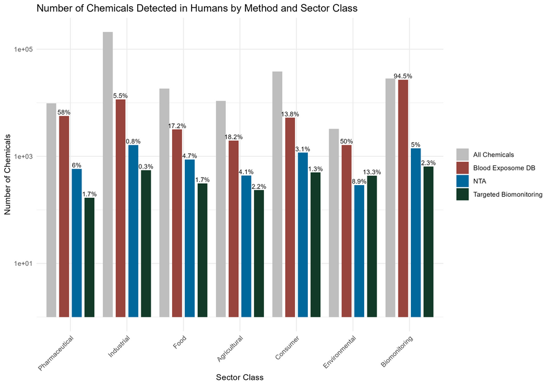

```r
do_method_plot = function() {
#Look at structure and sector space of the levels of chemicals detected in humans

load("Data/monitoring_landscape_data_2026-10-12.RData")
load("Data/blood_db_CIIW_curated.RData")
#load the most recent rocks_sector_table.RData file
#find the most recent file in the directory
files<-list.files("Data/categories", pattern = "rocks_sector_table.*\\.RData$", full.names = TRUE)
file <- files[order(file.info(files)$mtime, decreasing = TRUE)][1]  # Get the most recent
load(file)


j<-left_join(inventory_all_descriptors2, fingerprints, by=c("cichem_id"="cichem"))
j<-left_join(j, rocks_sector_table[,c("cichem_id","pharmaceutical","agricultural","food","consumer","industrial")], by=c("cichem_id"="cichem_id"))
j<-left_join(j, monitoring, by=c("cichem_id"="cichem_id"))
j<-left_join(j, BloodExposomeDB, by=c("cichem_id"="cichem_id"))

j[is.na(j)]<-0


#Make flags for trad, NTA, and BloodExposomeDB
cols <- c(
  "human.blood..whole.serum.plasma.",
  "human..other.tissues.or.fluids.",
  "urine",
  "skin.wipes",
  "breast.milk"
)

j$trad_flag <- apply(j[, cols], 1, max, na.rm = TRUE)

cols <- c(
  "NTA_biomonitoring_curation",
  "pooled_blood"
)
j$nta_flag<-apply(j[, cols], 1, max, na.rm = TRUE)

j2<-j[,c("cichem_id","densmap_1","densmap_2","trad_flag","nta_flag","BloodExposomeDB","pharmaceutical","industrial","food","agricultural","consumer","inventory_environmental","inventory_biomonitoring")]

#Make a Bar Chart of the number of chemicals with traditional monitoring, NTA, BloodExposomeDB, by sector

j2_long <- j2 %>%
  pivot_longer(
    cols = c("pharmaceutical","industrial","food","agricultural","consumer","inventory_environmental","inventory_biomonitoring"),
    names_to = "sector_class",
    values_to = "sector_flag"
  ) %>%
  filter(sector_flag == 1)


toplot <- j2_long %>%
  pivot_longer(
    cols = c("trad_flag", "nta_flag", "BloodExposomeDB"),
    names_to = "method",
    values_to = "value"
  ) %>%
  filter(value == 1) %>%
  group_by(method, sector_class) %>%
  summarise(
    count = n_distinct(cichem_id),
    .groups = "drop"
  )

all_chems <- j2_long %>%
  group_by(sector_class) %>%
  summarise(
    count = n_distinct(cichem_id),
    .groups = "drop"
  ) %>%
  mutate(method = "All Chemicals")

toplot <- bind_rows(toplot, all_chems)

# Add % coverage relative to all chemicals in each sector
toplot_annot <- toplot %>%
  group_by(sector_class) %>%
  mutate(
    all_count = count[method == "All Chemicals"][1],
    pct_coverage = 100 * count / all_count,
    label = if_else(
      method == "All Chemicals",
      "   ",
      paste0(round(pct_coverage, 1), "%")
    )
  ) %>%
  ungroup()

toplot_annot$sector_class[toplot_annot$sector_class=="inventory_biomonitoring"]<-"biomonitoring"
toplot_annot$sector_class[toplot_annot$sector_class=="inventory_environmental"]<-"environmental"

#capitalize all
toplot_annot$sector_class<-capitalize_first(toplot_annot$sector_class)


sector_order <- c(
  "Pharmaceutical",
  "Industrial",
  "Food",
  "Agricultural",
  "Consumer",
  "Environmental",
  "Biomonitoring"
)

toplot_annot <- toplot_annot %>%
  mutate(
    sector_class = factor(sector_class, levels = sector_order)
  )

pd <- position_dodge(width = 0.9)

barplot <- ggplot(toplot_annot, aes(x = sector_class, y = count, fill = method)) +
geom_bar(
  stat = "identity",
  position = pd,
  width = 0.7
) +
  geom_text(
    data = toplot_annot,
    aes(label = label),
    position = pd,
    vjust = -0.3,
    size = 3
  ) +
  theme_minimal() +
  labs(
    title = "Number of Chemicals Detected in Humans by Method and Sector Class",
    x = "Sector Class",
    y = "Number of Chemicals"
  ) +
  scale_fill_manual(
    values = c(
      "trad_flag" = tradcolor,
      "nta_flag" = namcolor,
      "BloodExposomeDB" = bloodexcolor,
      "All Chemicals" = "gray"
    ),
labels = c(
   "trad_flag" = "Targeted Biomonitoring",
   "nta_flag" = "NTA",
   "BloodExposomeDB" = "Blood Exposome DB",
   "All Chemicals" = "All Chemicals"
)
  ) +
  theme(
    axis.text.x = element_text(angle = 45, hjust = 1)
  ) +
  scale_y_continuous(
    trans = "log10"
  )+ theme(legend.title = element_blank())

#Now do a densemap plot of the chemicals detected in humans by method

j3<-j[,c("cichem_id","densmap_1","densmap_2","trad_flag","nta_flag","BloodExposomeDB","inventory_biomonitoring")]

#plot Blood exposome points
p1<-ggplot(j3, aes(x=densmap_1, y=densmap_2)) +
  geom_point(data=j3[which(j3$inventory_biomonitoring==0),], aes(color="gray"),alpha=0.1, size=0.6, shape=16)+
  geom_point(data=j3[which(j3$BloodExposomeDB==1),], aes(color="Blood Exposome DB"),alpha=0.3, size=0.6, shape=16) +
  geom_point(data=j3[which(j3$nta_flag==1),], aes(color="NTA"), alpha=0.7, size=0.9, shape=16) +
  geom_point(data=j3[which(j3$trad_flag==1),], aes(color="Targeted Biomonitoring"), alpha=0.7, size=1, shape=16) +
  theme_minimal() +
  labs(title="Structure Space of Chemicals Detected in Humans", x=" ", y=" ") +
  scale_color_manual(values=c("Targeted Biomonitoring"=tradcolor, "NTA"=namcolor, "Blood Exposome DB"=bloodexcolor)) +
  theme(legend.title = element_blank()) +
  ylim(-5,20)+xlim(-10,20)+ guides(color = guide_legend(override.aes = list(size = 4, alpha = 1)))

list<-list(barplot, p1)

}

k<-do_method_plot()
filename<-"Output/biomonitoring_method_coverage.png"
ggsave(
  filename = filename,
  plot = k[[1]],
  width = 10,
  height = 7,
  dpi = 300
)
preview_file <- preview_png(filename,
  scale = 0.3
)
knitr::include_graphics(preview_file)
```

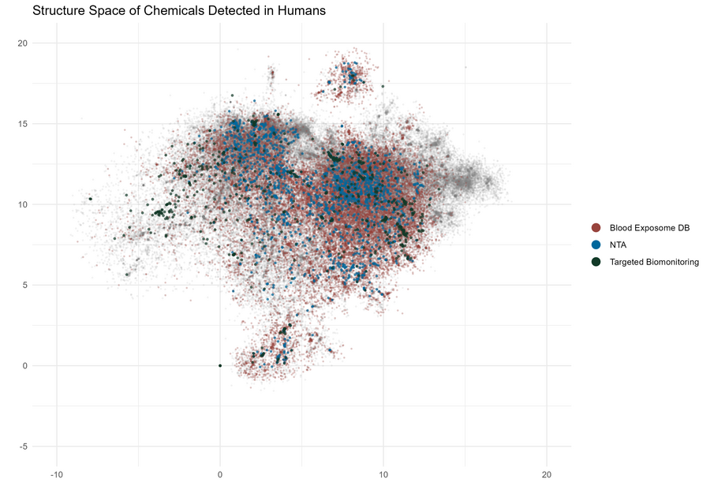

```r
k<-do_method_plot()
filename<-"Output/biomonitoring_method_mapping.png"
ggsave(
  filename = filename,
  plot = k[[2]],
#plot = p1,
  width = 10,
  height = 7,
  dpi = 300
)
preview_file <- preview_png(filename,
  scale = 0.3
)
knitr::include_graphics(preview_file)
```

Exposure prediction landscape plots: Figure 5, Figure S6, Figure S7

```r
#exposure prediction landscape
do_exposure_prediction_plot = function() {

j<-fingerprints
#j<-left_join(j,cichemid,by=c("cicomp_id"="cicomp"))
tmp<-left_join(inventory_all_descriptors2, j, by=c("cichem_id"="cichem"))

tmp$x<-tmp$densmap_1
tmp$y<-tmp$densmap_2

#Inferences from CIEXPO-Intake
load("data/inferences.RData")

#load in new SEEM 3.1 predictions for inventory chemicals
deltas<-readRDS("data/seem/inventory_deltas_2026-07-26.RDS")
load("data/seem/seem-preds-2026-07-26.RData")
load("data/seem/chem.preds-2026-07-26.RData")

seem<-cbind(a, seem.preds)

outsideseemdomain<-deltas$cichem[which(deltas$delta.Res.pred<0.5 & deltas$delta.Indust.pred<0.5 & deltas$delta.Diet.pred<0.5 & deltas$delta.Pest.pred<0.5)]

paste0("Number of chemicals outside SEEM domain: ", length(outsideseemdomain))

seem$in_seem_ad<-1
seem$seem_diet<-0
seem$seem_industrial<-0
seem$seem_consumer<-0
seem$seem_pesticide<-0
seem$seem_diet<-0
seem$seem_industrial<-0
seem$seem_consumer<-0
seem$seem_pesticide<-0
seem$seem_diet[which(seem$delta.Diet.pred>0.5)]<-1
seem$seem_industrial[which(seem$delta.Indust.pred>0.5)]<-1
seem$seem_consumer[which(seem$delta.Res.pred>0.5)]<-1
seem$seem_pesticide[which(seem$delta.Pest.pred>0.5)]<-1
seem$in_seem_ad[which(seem$cichem_id %in% outsideseemdomain)]<-0

#Make a bar plot showing what fraction of each sector is in domain of each pathway.

j<-left_join(tmp, seem[,c("cichem","seem_diet","seem_industrial","seem_consumer","seem_pesticide","in_seem_ad","seem3","seem3.u95","seem3.l95")], by=c("cichem_id"="cichem"))
j<-j[which(j$cichem_id %in% seem$cichem),] #only include chemicals we could run
j<-left_join(j, rocks_sector_table[,c("cichem_id","pharmaceutical","agricultural","food","consumer","industrial")], by=c("cichem_id"="cichem_id"))

#Make a Bar Chart of the number of chemicals trad, nta, blood by sector

j2<-j[,c("cichem_id","densmap_1","densmap_2","seem_diet","seem_industrial","seem_pesticide","seem_consumer","in_seem_ad","seem3","seem3.u95","seem3.l95","pharmaceutical","industrial","food","agricultural","consumer","inventory_environmental","inventory_biomonitoring")]


j2_long <- j2 %>%
  pivot_longer(
    cols = c("pharmaceutical","industrial","food","agricultural","consumer","inventory_environmental","inventory_biomonitoring"),
    names_to = "sector_class",
    values_to = "sector_flag"
  ) %>%
  filter(sector_flag == 1)

toplot <- j2_long %>%
  pivot_longer(
    cols = c("seem_diet", "seem_industrial", "seem_pesticide", "seem_consumer"),
    names_to = "Pathway",
    values_to = "value"
  ) %>%
  group_by(Pathway, sector_class) %>%
  summarise(
    count = n_distinct(cichem_id),
    #count where ==1
    in_domain = sum(value == 1, na.rm = TRUE)/count,
    .groups = "drop"
  )

toplot$sector_class[toplot$sector_class=="inventory_biomonitoring"]<-"biomonitoring"
toplot$sector_class[toplot$sector_class=="inventory_environmental"]<-"environmental"
toplot$sector_class<-capitalize_first(toplot$sector_class)

sector_order <- c(
  "Pharmaceutical",
  "Industrial",
  "Food",
  "Agricultural",
  "Consumer",
  "Environmental",
  "Biomonitoring"
)

toplot <- toplot %>%
  mutate(
    sector_class = factor(sector_class, levels = sector_order)
  )

#Make 4 plots, one for each pathway, showing overlapping bars with the total chem count behind and the count in
#domain in front

library(ggplot2)

g1 <- ggplot(
  toplot[toplot$Pathway == "seem_consumer", ],
  aes(x = sector_class)
) +
  geom_col(
    aes(y = 1),
    fill = "grey80",
    width = 0.8
  ) +
  geom_col(
    aes(y = in_domain),
    fill = "#2C7FB8",
    width = 0.8
  ) +
  geom_text(
    aes(y = 1.02, label = count),
    vjust = 0,
    size = 4
  ) +
  coord_cartesian(ylim = c(0, 1.1), clip = "off") +
  labs(
    x = NULL,
    y = "Fraction in Domain"
  ) +
  theme_minimal() +
  theme(
    axis.text.x = element_text(angle = 45, hjust = 1),
    legend.title = element_blank()
  )+ggtitle("SEEM Consumer Pathway")


g2 <- ggplot(
  toplot[toplot$Pathway == "seem_diet", ],
  aes(x = sector_class)
) +
  geom_col(
    aes(y = 1),
    fill = "grey80",
    width = 0.8
  ) +
  geom_col(
    aes(y = in_domain),
    fill = "#2C7FB8",
    width = 0.8
  ) +
  geom_text(
    aes(y = 1.02, label = count),
    vjust = 0,
    size = 4
  ) +
  coord_cartesian(ylim = c(0, 1.1), clip = "off") +
  labs(
    x = NULL,
    y = "Fraction in Domain"
  ) +
  theme_minimal() +
  theme(
    axis.text.x = element_text(angle = 45, hjust = 1),
    legend.title = element_blank()
  )+ggtitle("SEEM Dietary Pathway")

g3 <- ggplot(
  toplot[toplot$Pathway == "seem_pesticide", ],
  aes(x = sector_class)
) +
  geom_col(
    aes(y = 1),
    fill = "grey80",
    width = 0.8
  ) +
  geom_col(
    aes(y = in_domain),
    fill = "#2C7FB8",
    width = 0.8
  ) +
  geom_text(
    aes(y = 1.02, label = count),
    vjust = 0,
    size = 4
  ) +
  coord_cartesian(ylim = c(0, 1.1), clip = "off") +
  labs(
    x = NULL,
    y = "Fraction in Domain"
  ) +
  theme_minimal() +
  theme(
    axis.text.x = element_text(angle = 45, hjust = 1),
    legend.title = element_blank()
  )+ggtitle("SEEM Pesticide Pathway")

g4 <- ggplot(
  toplot[toplot$Pathway == "seem_industrial", ],
  aes(x = sector_class)
) +
  geom_col(
    aes(y = 1),
    fill = "grey80",
    width = 0.8
  ) +
  geom_col(
    aes(y = in_domain),
    fill = "#2C7FB8",
    width = 0.8
  ) +
  geom_text(
    aes(y = 1.02, label = count),
    vjust = 0,
    size = 4
  ) +
  coord_cartesian(ylim = c(0, 1.1), clip = "off") +
  labs(
    x = NULL,
    y = "Fraction in Domain"
  ) +
  theme_minimal() +
  theme(
    axis.text.x = element_text(angle = 45, hjust = 1),
    legend.title = element_blank()
  )+ggtitle("SEEM Industrial Pathway")

library(patchwork)
#make 2x 2
pathway_coverage<-(g1 | g2) / (g3 | g4) + plot_layout(guides = "collect") & theme(legend.position = "bottom")

j$combo_sector<-paste0(j$pharmaceutical,j$industrial,j$food,j$agricultural,j$consumer,j$inventory_environmental,j$inventory_biomonitoring)

combocounts<-data.frame(table(j$combo_sector))
```

```r
keepcombos<-combocounts[which(combocounts$Freq>200),]

#generate a ridgeline plot of seem_50 of chemicals for each combo_sector, colored by the number of chemicals in each combo_sector

library(dplyr)
library(ggplot2)
library(ggridges)
library(forcats)


toplot<-j[which(j$combo_sector %in% keepcombos$Var1),]

cats <- c("pharmaceutical","agricultural","food","consumer","industrial","inventory_biomonitoring","inventory_environmental")
catnames <- c("Pharmaceutical","Agricultural","Food","Consumer","Industrial","Biomonitoring","Environmental" )

toplot$combo_name <- apply(
  toplot[, cats],
  1,
  function(x) {
    paste(catnames[as.logical(x)], collapse = "+")
  }
)

combo_levels <- toplot %>%
  group_by(combo_name) %>%
  summarise(
    median_log = median(log10(seem3), na.rm = TRUE),
    .groups = "drop"
  ) %>%
  arrange(median_log) %>%
  pull(combo_name)


ridge_dat <- toplot %>%
  filter(
    !is.na(combo_name),
    !is.na(seem3),
    is.finite(seem3)
  ) %>%
  group_by(combo_name) %>%
  mutate(
    median_exposure = median(seem3, na.rm = TRUE),
    n_combo = n()
  ) %>%
  ungroup() %>%
  mutate(
    combo_name = factor(combo_name, combo_levels)
  )


ridge<-ggplot(
  ridge_dat,
  aes(
    x = seem3,
    y = combo_name,
    fill = after_stat(x)
  )
) +
  geom_density_ridges_gradient(
    scale = 2.5,
    rel_min_height = 0.01,
    alpha = 0.9,
    color = "white",
    linewidth = 0.25
  ) +
  scale_x_log10() +
  scale_fill_viridis_c(
    option = "magma",
    trans = "log10",
    name = "Exposure"
  ) +
  labs(
    x = "Predicted exposure",
    y = NULL,
    title = "Distribution across chemicals of SEEM3.1 Median Intakes (mg/kg-BW/day)"
  ) +
  theme_minimal() +
  theme(
    axis.text.y = element_text(size = 7),
    panel.grid.major.y = element_blank(),
    legend.title = element_text(size = 9),
    legend.text = element_text(size = 8)
  )

#merge
#j<-left_join(j,cichemid,by=c("cicomp_id"="cicomp"))
tmp<-left_join(inventory_all_descriptors2, fingerprints, by=c("cichem_id"="cichem"))
tmp<-left_join(tmp, seem[,c("cichem","seem_diet","seem_industrial","seem_consumer","seem_pesticide","in_seem_ad","seem3","seem3.u95","seem3.l95")], by=c("cichem_id"="cichem"))



#tmp<-tmp[which(!is.na(tmp$densmap_1)),] #structurable

#Other predictions from CIExpo-Intake
tmp$seem_class<-"No Exposure Prediction"
tmp$seem_class[which(tmp$cichem_id %in% seem$cichem)]<-"SEEM Prediction"
tmp$seem_class[which(tmp$cichem_id %in% inferences$cichem_id)]<-"Inferred from NHANES"
tmp$seem_class[which(tmp$cichem_id %in% outsideseemdomain)]<-"Outside SEEM Applicability Domain"

tmp$uncrange<-log10(tmp$seem3.u95-tmp$seem3.l95)
tmp$uncrange<-tmp$seem3.u95-tmp$seem3.l95
#tmp$uncrange<-log10(tmp$seem3.u95)-log10(tmp$seem3.l95)


#make histogram of uncrange by sector_class
seemuncmain<-ggplot(
  tmp[tmp$seem_class != "Outside SEEM Applicability Domain", ],
  aes(x = sector_class, y = uncrange)
) +
#  geom_boxplot(outlier.shape = NA) +
    geom_boxplot() +
  scale_y_log10() +
  xlab("") +
  ylab("Width of 95% Credible Interval (mg/kg-BW/day)")+
  coord_cartesian(
     ylim = c(1e-12, 1e6)
   )

seemuncinset<-ggplot(
  tmp[tmp$seem_class != "Outside SEEM Applicability Domain", ],
  aes(x = sector_class, y = uncrange)
) +
geom_boxplot(outlier.shape = NA) +
#    geom_boxplot() +
  scale_y_log10() +
  xlab("") +
  ylab("")+ coord_cartesian(
    ylim = c(5e-5, 5e-3)
  )

seemuncinset <- seemuncinset +
  theme(
    axis.title = element_blank(),
    axis.text.x = element_blank(),
    axis.ticks.x = element_blank()
  )

library(patchwork)


seemunc<-
seemuncmain +
  inset_element(
    seemuncinset,
    left = 0.05,
    bottom = 0.65,
    right = 0.45,
    top = 1
  )


tmp2 <- tmp %>%
  mutate(seem_class = factor(seem_class, levels = c("No Exposure Prediction", "SEEM Prediction", "Inferred from NHANES","Outside SEEM Applicability Domain"))) %>%
  arrange(seem_class)

typecolors<-c("SEEM Prediction"=  "#00689C","Inferred from NHANES"=  "black","No Exposure Prediction"=  "#BCBEC0","Outside SEEM Applicability Domain"="#CA0123")

seemclass<-ggplot(tmp2, aes(x=densmap_1, y=densmap_2)) +
  theme_minimal() +
  #labs(title="t-SNE of Chemical Descriptors Colored by Sector Class") +
  geom_point(data=tmp2[which(tmp2$seem_class=="No Exposure Prediction"),], aes(color="No Exposure Prediction"),alpha=0.1, size=0.8, shape=16)+
  geom_point(data=tmp2[which(tmp2$seem_class=="SEEM Prediction"),], aes(color="SEEM Prediction"),alpha=0.3, size=0.8, shape=16) +
  geom_point(data=tmp2[which(tmp2$seem_class=="Outside SEEM Applicability Domain"),], aes(color="Outside SEEM Applicability Domain"), alpha=0.4, size=0.6, shape=16) +
   geom_point(data=tmp2[which(tmp2$seem_class=="Inferred from NHANES"),], aes(color="Inferred from NHANES"), alpha=0.7, size=1.5, shape=16) +
  theme_minimal() +
  scale_color_manual(values=typecolors) + xlab("DensMap Dimension 1")+ylab("DensMap Dimension 2")+
  theme(legend.title = element_blank(),legend.position = "bottom",
legend.text = element_text(size = 12), # legend labels
axis.title.x = element_text(size = 16), # x-axis title
axis.title.y = element_text(size = 16), # y-axis title
axis.text.x = element_text(size = 12), # x-axis tick labels
axis.text.y = element_text(size = 12))+ # y-axis tick labels) +
  ylim(-5,20)+xlim(-10,20)+ guides(color = guide_legend(override.aes = list(size = 4, alpha = 1)))


tmp3<-dplyr::select(tmp, densmap_1, densmap_2, cichem_id)

tmp3$path_class<-"No Pathway"
haspest<-deltas$cichem[which(deltas$delta.Pest.pred>0.5)]
hasindustrial<-deltas$cichem[which(deltas$delta.Indust.pred>0.5)]
hasconsumer<-deltas$cichem[which(deltas$delta.Res.pred>0.5)]
hasdietary<-deltas$cichem[which(deltas$delta.Diet.pred>0.5)]

tmp3$path_class[which(tmp3$cichem_id %in% haspest)]<-"Pesticide Pathway"
tmp3$path_class[which(tmp3$cichem_id %in% hasindustrial)]<-"Industrial Pathway"
tmp3$path_class[which(tmp3$cichem_id %in% hasconsumer)]<-"Consumer Pathway"
tmp3$path_class[which(tmp3$cichem_id %in% hasdietary)]<-"Dietary Pathway"
```

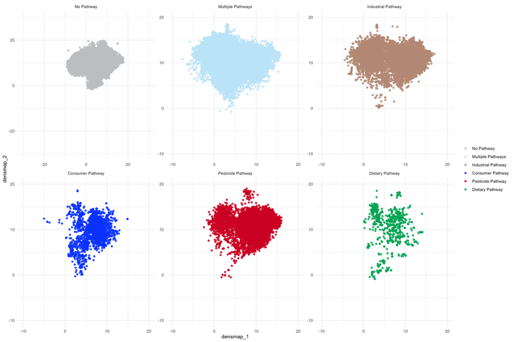

```r
#if it has one or more pathways, set "Multiple Pathways"
tmp3$path_class[which(tmp3$cichem_id %in% haspest & tmp3$cichem_id %in% hasindustrial)]<-"Multiple Pathways"
tmp3$path_class[which(tmp3$cichem_id %in% haspest & tmp3$cichem_id %in% hasconsumer)]<-"Multiple Pathways"
tmp3$path_class[which(tmp3$cichem_id %in% haspest & tmp3$cichem_id %in% hasdietary)]<-"Multiple Pathways"
tmp3$path_class[which(tmp3$cichem_id %in% hasindustrial & tmp3$cichem_id %in% hasconsumer)]<-"Multiple Pathways"
tmp3$path_class[which(tmp3$cichem_id %in% hasindustrial & tmp3$cichem_id %in% hasdietary)]<-"Multiple Pathways"
tmp3$path_class[which(tmp3$cichem_id %in% hasconsumer & tmp3$cichem_id %in% hasdietary)]<-"Multiple Pathways"
tmp3$path_class[which(tmp3$cichem_id %in% haspest & tmp3$cichem_id %in% hasindustrial & tmp3$cichem_id %in% hasconsumer)]<-"Multiple Pathways"
tmp3$path_class[which(tmp3$cichem_id %in% haspest & tmp3$cichem_id %in% hasindustrial & tmp3$cichem_id %in% hasdietary)]<-"Multiple Pathways"

tmp3 <- tmp3 %>%
  mutate(path_class = factor(path_class, levels = c("No Pathway", "Multiple Pathways","Industrial Pathway","Consumer Pathway","Pesticide Pathway","Dietary Pathway"))) %>%
  arrange(path_class)

pathcolors<- c("No Pathway"="#BCBEC0", "Multiple Pathways"="#BCE4F7","Industrial Pathway"="#B38874","Consumer Pathway"="#0A32FF","Pesticide Pathway"="#CA0123","Dietary Pathway"="#00A451")

library(ggh4x)
seemplot<-ggplot(tmp3, aes(x=densmap_1, y=densmap_2, color=path_class)) +
  geom_point(alpha=0.8) +
  theme_minimal() +
  #labs(title="t-SNE of Chemical Descriptors Colored by Sector Class") +
  scale_color_manual(values=pathcolors) +
  theme(legend.title = element_blank())+
  facet_wrap(~path_class,scales = "free")

seemplot<-seemplot +
  facetted_pos_scales(
    y = list(
      path_class == "No Pathway" ~ scale_y_continuous(limits = c(-30, 30)),
      path_class == "Multiple Pathways" ~ scale_y_continuous(limits = c(-10, 20)),
      path_class == "Industrial Pathway" ~ scale_y_continuous(limits = c(-10, 20)),
      path_class == "Consumer Pathway" ~ scale_y_continuous(limits = c(-10, 20)),
      path_class == "Pesticide Pathway" ~ scale_y_continuous(limits = c(-10, 20)),
      path_class == "Dietary Pathway" ~ scale_y_continuous(limits = c(-10, 20))
    ),
    x = list(
      path_class == "No Pathway" ~ scale_x_continuous(limits = c(-30, 30)),
      path_class == "Multiple Pathways" ~ scale_x_continuous(limits = c(-10, 20)),
      path_class == "Industrial Pathway" ~ scale_x_continuous(limits = c(-10, 20)),
      path_class == "Consumer Pathway" ~ scale_x_continuous(limits = c(-10, 20)),
      path_class == "Pesticide Pathway" ~ scale_x_continuous(limits = c(-10, 20)),
      path_class == "Dietary Pathway" ~ scale_x_continuous(limits = c(-10, 20))
    )
  )


#make a barchart of the range of uncertainty bounds by sector


list(seemplot, pathway_coverage,seemclass, ridge,seemunc)

}

k<-do_exposure_prediction_plot()

ggsave(
  filename = "Output/exposure_pathway_landscape.png",
  plot = k[[1]],
  width = 15,
  height = 10,
  dpi = 300
)
preview_file <- preview_png("Output/exposure_pathway_landscape.png",
  scale = 0.3
)
knitr::include_graphics(preview_file)
```

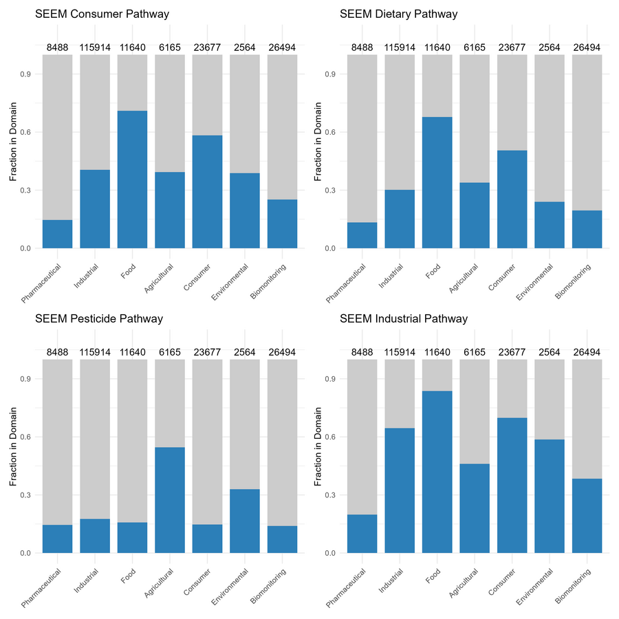

```r
ggsave(
  filename = "Output/pathway_coverage.png",
  plot = k[[2]],
  width = 10,
  height = 10,
  dpi = 300
)
preview_file <- preview_png("Output/pathway_coverage.png",
  scale = 0.3
)
knitr::include_graphics(preview_file)
```

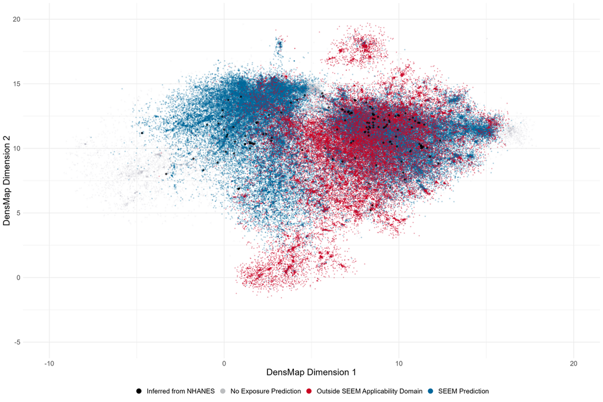

```r
ggsave(
  filename = "Output/seem_availability_landscape.png",
  plot = k[[3]],
  width = 15,
  height = 10,
  dpi = 300
)
preview_file <- preview_png("Output/seem_availability_landscape.png",
  scale = 0.3
)
knitr::include_graphics(preview_file)
```

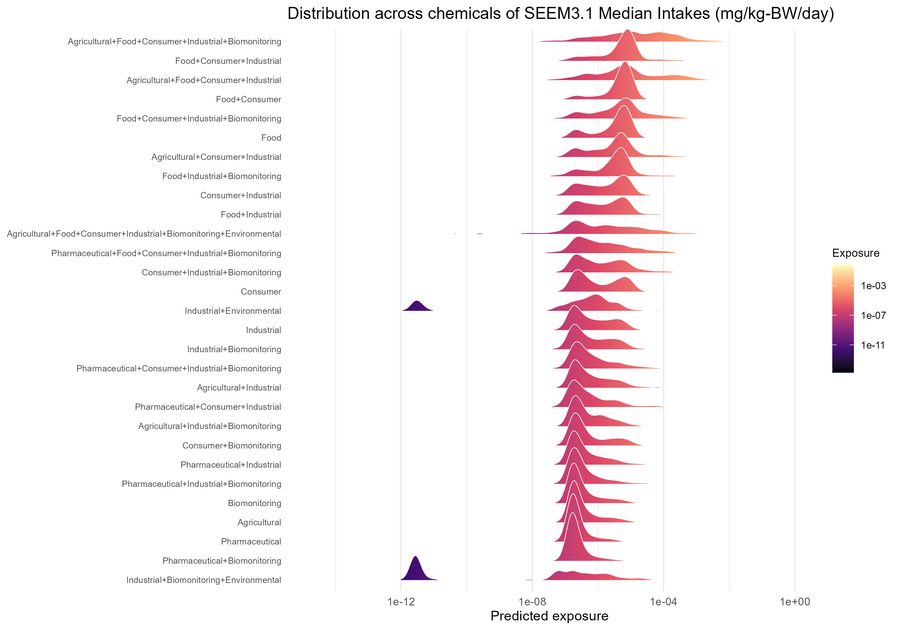

```r
  ggsave(
  filename = "Output/seem_ridge.png",
  plot = k[[4]],
  width = 10,
  height = 7,
  dpi = 300
)
    preview_file <- preview_png("Output/seem_ridge.png",
  scale = 0.3
)
knitr::include_graphics(preview_file)
```

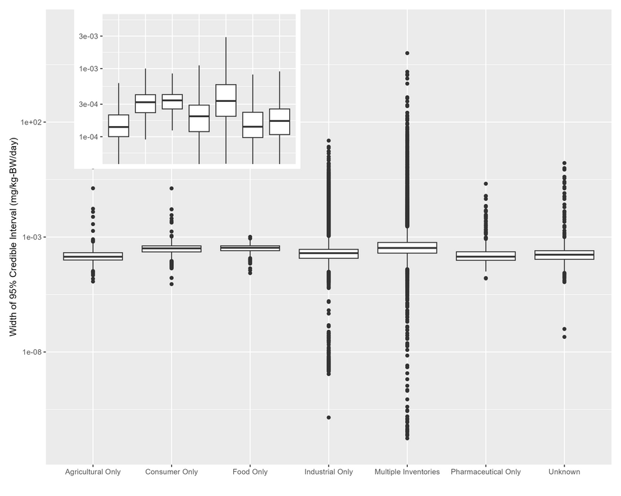

```r
  ggsave(
  filename = "Output/seem_unc.png",
  plot = k[[5]],
  width = 10,
  height = 8,
  dpi = 300
)
preview_file <- preview_png("Output/seem_unc.png",
  scale = 0.3
)
knitr::include_graphics(preview_file)
```